# Homework 2

$\Phi$ is a very sacred number called the "Golden Ratio". Some people believe that it has magick properties which allow us, mere mortals, to understand more than just the natural world. It is approximately equal to . . .

1.6180339887498948482045868343656381177203091798057

Including the 1 preceding to the decimal, what is the mode of the first 24 digits of $\Phi$?

The most frequent number is $8$, therefore the mode is $8.00$

$\Phi$ is a very sacred number called the "Golden Ratio". Some people believe that it has magick properties which allow us, mere mortals, to understand more than just the natural world. It is approximately equal to . . .

1.6180339887498948482045868343656381177203091798057

Including the 1 preceding to the decimal, what is the mode of the first 23 digits of $\Phi$?

The most frequent number is $8$, therefore the mode is $8.00$

$\Phi$ is a very sacred number called the "Golden Ratio". Some people believe that it has magick properties which allow us, mere mortals, to understand more than just the natural world. It is approximately equal to . . .

1.6180339887498948482045868343656381177203091798057

Including the 1 preceding to the decimal, what is the mode of the first 24 digits of $\Phi$?

The most frequent number is $8$, therefore the mode is $8.00$

$\Phi$ is a very sacred number called the "Golden Ratio". Some people believe that it has magick properties which allow us, mere mortals, to understand more than just the natural world. It is approximately equal to . . .

1.6180339887498948482045868343656381177203091798057

Including the 1 preceding to the decimal, what is the mode of the first 19 digits of $\Phi$?

The most frequent number is $8$, therefore the mode is $8.00$

$\Phi$ is a very sacred number called the "Golden Ratio". Some people believe that it has magick properties which allow us, mere mortals, to understand more than just the natural world. It is approximately equal to . . .

1.6180339887498948482045868343656381177203091798057

Including the 1 preceding to the decimal, what is the mode of the first 23 digits of $\Phi$?

The most frequent number is $8$, therefore the mode is $8.00$

$\Phi$ is a very sacred number called the "Golden Ratio". Some people believe that it has magick properties which allow us, mere mortals, to understand more than just the natural world. It is approximately equal to . . .

1.6180339887498948482045868343656381177203091798057

Including the 1 preceding to the decimal, what is the mode of the first 22 digits of $\Phi$?

The most frequent number is $8$, therefore the mode is $8.00$

$\Phi$ is a very sacred number called the "Golden Ratio". Some people believe that it has magick properties which allow us, mere mortals, to understand more than just the natural world. It is approximately equal to . . .

1.6180339887498948482045868343656381177203091798057

Including the 1 preceding to the decimal, what is the mode of the first 21 digits of $\Phi$?

The most frequent number is $8$, therefore the mode is $8.00$

$\Phi$ is a very sacred number called the "Golden Ratio". Some people believe that it has magick properties which allow us, mere mortals, to understand more than just the natural world. It is approximately equal to . . .

1.6180339887498948482045868343656381177203091798057

Including the 1 preceding to the decimal, what is the mode of the first 24 digits of $\Phi$?

The most frequent number is $8$, therefore the mode is $8.00$

$\Phi$ is a very sacred number called the "Golden Ratio". Some people believe that it has magick properties which allow us, mere mortals, to understand more than just the natural world. It is approximately equal to . . .

1.6180339887498948482045868343656381177203091798057

Including the 1 preceding to the decimal, what is the mode of the first 16 digits of $\Phi$?

The most frequent number is $8$, therefore the mode is $8.00$

$\Phi$ is a very sacred number called the "Golden Ratio". Some people believe that it has magick properties which allow us, mere mortals, to understand more than just the natural world. It is approximately equal to . . .

1.6180339887498948482045868343656381177203091798057

Including the 1 preceding to the decimal, what is the mode of the first 23 digits of $\Phi$?

The most frequent number is $8$, therefore the mode is $8.00$

What is the median of the following numbers:

42.5, 18.3, 41.9, 25, 49.9, 91.9, 63.2, 48.6, 96.9, 64.9, 32.4, 93.5

**Answer:** 49.25

**Solution:**

Sort the Data:

$18.3, 25, 32.4, 41.9, 42.5, 48.6, 49.9, 63.2, 64.9, 91.9, 93.5, 96.9$

Find the value(s) in the middle position of the data set:

$48.6$ and $49.9$

If there are two values (because there is an even number of data points), take the mean of those to establish the true midpoint:

$\frac{48.6 + 49.9}{2} = 49.25$

**R code:**

```
x <- c(42.5, 18.3, 41.9, 25, 49.9, 91.9, 63.2, 48.6, 96.9, 64.9, 32.4, 93.5)
median(x)
```

What is the median of the following numbers:

43.2, 69, 8.7, 1.1, 87.6, 9.8, 98.1, 66.5, 38.5, 85.3, 57, 85.8, 3.6, 15.3, 69.7, 93.3, 80.6, 62.3, 25, 10.4

**Answer:** 59.65

**Solution:**

Sort the Data:

$1.1, 3.6, 8.7, 9.8, 10.4, 15.3, 25, 38.5, 43.2, 57, 62.3, 66.5, 69, 69.7, 80.6, 85.3, 85.8, 87.6, 93.3, 98.1$

Find the value(s) in the middle position of the data set:

$57$ and $62.3$

If there are two values (because there is an even number of data points), take the mean of those to establish the true midpoint:

$\frac{57 + 62.3}{2} = 59.65$

**R code:**

```
x <- c(43.2, 69, 8.7, 1.1, 87.6, 9.8, 98.1, 66.5, 38.5, 85.3, 57, 85.8, 3.6, 15.3, 69.7, 93.3, 80.6, 62.3, 25, 10.4)
median(x)
```

What is the median of the following numbers:

75.2, 51.3, 75.5, 31, 29.3, 28, 83.6, 67.2, 79.8, 93.7, 45.3, 97, 87.4, 14.7, 36.6, 83.7, 11.1, 1.4, 81.7, 6, 37.1, 98.2

**Answer:** 59.25

**Solution:**

Sort the Data:

$1.4, 6, 11.1, 14.7, 28, 29.3, 31, 36.6, 37.1, 45.3, 51.3, 67.2, 75.2, 75.5, 79.8, 81.7, 83.6, 83.7, 87.4, 93.7, 97, 98.2$

Find the value(s) in the middle position of the data set:

$51.3$ and $67.2$

If there are two values (because there is an even number of data points), take the mean of those to establish the true midpoint:

$\frac{51.3 + 67.2}{2} = 59.25$

**R code:**

```
x <- c(75.2, 51.3, 75.5, 31, 29.3, 28, 83.6, 67.2, 79.8, 93.7, 45.3, 97, 87.4, 14.7, 36.6, 83.7, 11.1, 1.4, 81.7, 6, 37.1, 98.2)
median(x)
```

What is the median of the following numbers:

31.9, 38.7, 30.4, 6.1, 11.1, 39.8, 92.5, 14.9, 15.6, 81.6

**Answer:** 31.15

**Solution:**

Sort the Data:

$6.1, 11.1, 14.9, 15.6, 30.4, 31.9, 38.7, 39.8, 81.6, 92.5$

Find the value(s) in the middle position of the data set:

$30.4$ and $31.9$

If there are two values (because there is an even number of data points), take the mean of those to establish the true midpoint:

$\frac{30.4 + 31.9}{2} = 31.15$

**R code:**

```
x <- c(31.9, 38.7, 30.4, 6.1, 11.1, 39.8, 92.5, 14.9, 15.6, 81.6)
median(x)
```

What is the median of the following numbers:

21.6, 28.8, 96.3, 97.9, 34.8, 10.8, 38, 55.4, 56.2, 77.7, 66.9, 2.6, 21.4, 58.9, 46.2, 60, 11.8, 45.4, 59, 57.5, 76.7, 9.4, 45.8, 42.1

**Answer:** 46

**Solution:**

Sort the Data:

$2.6, 9.4, 10.8, 11.8, 21.4, 21.6, 28.8, 34.8, 38, 42.1, 45.4, 45.8, 46.2, 55.4, 56.2, 57.5, 58.9, 59, 60, 66.9, 76.7, 77.7, 96.3, 97.9$

Find the value(s) in the middle position of the data set:

$45.8$ and $46.2$

If there are two values (because there is an even number of data points), take the mean of those to establish the true midpoint:

$\frac{45.8 + 46.2}{2} = 46$

**R code:**

```
x <- c(21.6, 28.8, 96.3, 97.9, 34.8, 10.8, 38, 55.4, 56.2, 77.7, 66.9, 2.6, 21.4, 58.9, 46.2, 60, 11.8, 45.4, 59, 57.5, 76.7, 9.4, 45.8, 42.1)
median(x)
```

What is the median of the following numbers:

50.2, 12.6, 39.1, 76.1, 41.4, 36, 92, 47.9, 59, 25.2, 73.9, 51.8, 90.8, 37.7, 27.2, 51.4, 15.1, 3.8, 70.8, 74.2, 67.5, 35.6, 16.9, 5.3

**Answer:** 44.65

**Solution:**

Sort the Data:

$3.8, 5.3, 12.6, 15.1, 16.9, 25.2, 27.2, 35.6, 36, 37.7, 39.1, 41.4, 47.9, 50.2, 51.4, 51.8, 59, 67.5, 70.8, 73.9, 74.2, 76.1, 90.8, 92$

Find the value(s) in the middle position of the data set:

$41.4$ and $47.9$

If there are two values (because there is an even number of data points), take the mean of those to establish the true midpoint:

$\frac{41.4 + 47.9}{2} = 44.65$

**R code:**

```
x <- c(50.2, 12.6, 39.1, 76.1, 41.4, 36, 92, 47.9, 59, 25.2, 73.9, 51.8, 90.8, 37.7, 27.2, 51.4, 15.1, 3.8, 70.8, 74.2, 67.5, 35.6, 16.9, 5.3)
median(x)
```

What is the median of the following numbers:

43.3, 10.3, 2.3, 25.8, 30.9, 85.6, 72.8, 89.2, 12.4, 44.5, 67.2, 10.9

**Answer:** 37.1

**Solution:**

Sort the Data:

$2.3, 10.3, 10.9, 12.4, 25.8, 30.9, 43.3, 44.5, 67.2, 72.8, 85.6, 89.2$

Find the value(s) in the middle position of the data set:

$30.9$ and $43.3$

If there are two values (because there is an even number of data points), take the mean of those to establish the true midpoint:

$\frac{30.9 + 43.3}{2} = 37.1$

**R code:**

```
x <- c(43.3, 10.3, 2.3, 25.8, 30.9, 85.6, 72.8, 89.2, 12.4, 44.5, 67.2, 10.9)
median(x)
```

What is the median of the following numbers:

51.2, 80, 86.7, 37.4, 11.1, 70.5, 47.7, 55.1, 15.4, 41.7, 95.1, 69.4, 71.7, 48.9, 11.5, 78.6, 41.2, 65.9

**Answer:** 53.15

**Solution:**

Sort the Data:

$11.1, 11.5, 15.4, 37.4, 41.2, 41.7, 47.7, 48.9, 51.2, 55.1, 65.9, 69.4, 70.5, 71.7, 78.6, 80, 86.7, 95.1$

Find the value(s) in the middle position of the data set:

$51.2$ and $55.1$

If there are two values (because there is an even number of data points), take the mean of those to establish the true midpoint:

$\frac{51.2 + 55.1}{2} = 53.15$

**R code:**

```
x <- c(51.2, 80, 86.7, 37.4, 11.1, 70.5, 47.7, 55.1, 15.4, 41.7, 95.1, 69.4, 71.7, 48.9, 11.5, 78.6, 41.2, 65.9)
median(x)
```

What is the median of the following numbers:

25.3, 38.8, 82.7, 52.2, 61, 35.9, 59.4, 30.4, 70.1, 96.3

**Answer:** 55.8

**Solution:**

Sort the Data:

$25.3, 30.4, 35.9, 38.8, 52.2, 59.4, 61, 70.1, 82.7, 96.3$

Find the value(s) in the middle position of the data set:

$52.2$ and $59.4$

If there are two values (because there is an even number of data points), take the mean of those to establish the true midpoint:

$\frac{52.2 + 59.4}{2} = 55.8$

**R code:**

```
x <- c(25.3, 38.8, 82.7, 52.2, 61, 35.9, 59.4, 30.4, 70.1, 96.3)
median(x)
```

What is the median of the following numbers:

81.4, 98.2, 73.9, 23.5, 29.4, 90.5, 30, 38.7, 4.7, 13.1, 97.9, 64.2, 59, 29.9

**Answer:** 48.85

**Solution:**

Sort the Data:

$4.7, 13.1, 23.5, 29.4, 29.9, 30, 38.7, 59, 64.2, 73.9, 81.4, 90.5, 97.9, 98.2$

Find the value(s) in the middle position of the data set:

$38.7$ and $59$

If there are two values (because there is an even number of data points), take the mean of those to establish the true midpoint:

$\frac{38.7 + 59}{2} = 48.85$

**R code:**

```
x <- c(81.4, 98.2, 73.9, 23.5, 29.4, 90.5, 30, 38.7, 4.7, 13.1, 97.9, 64.2, 59, 29.9)
median(x)
```

The chart below shows how Renee spends their time in a typical weekday. How many hours in a 24 hour day does Renee spend doing something other than sleeping or leisure?

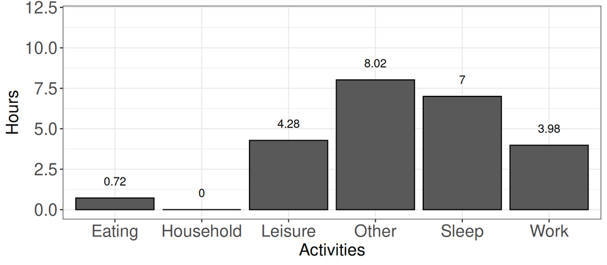

**Answer:** 12.72

**R code:**

```
24 - 7 - 4.28
```

The chart below shows how Jared spends their time in a typical weekday. How many hours in a 24 hour day does Jared spend doing something other than sleeping or leisure?

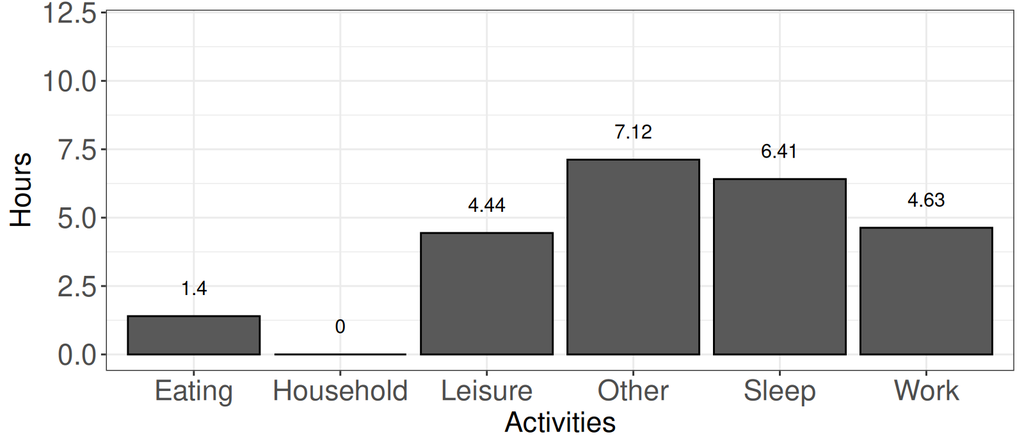

**Answer:** 13.15

**R code:**

```
24 - 6.41 - 4.44
```

The chart below shows how Chance spends their time in a typical weekday. How many hours in a 24 hour day does Chance spend doing something other than sleeping or leisure?

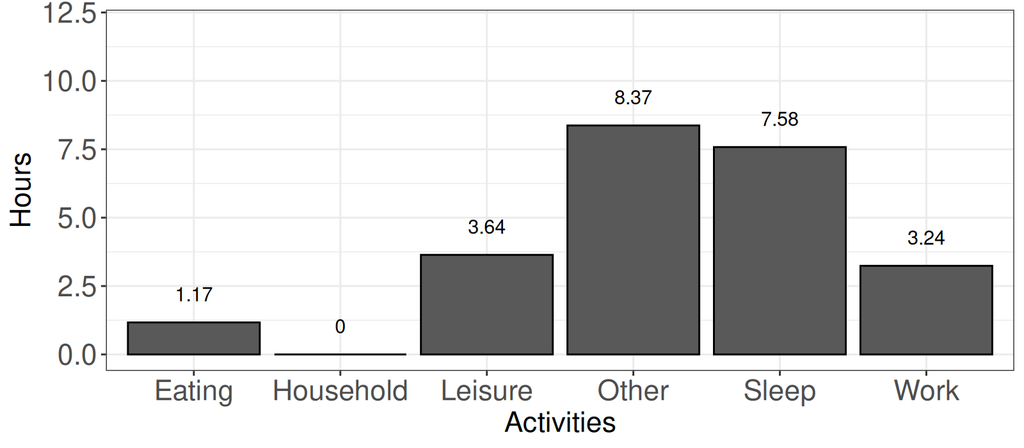

**Answer:** 12.78

**R code:**

```
24 - 7.58 - 3.64
```

The chart below shows how Patrick spends their time in a typical weekday. How many hours in a 24 hour day does Patrick spend doing something other than sleeping or leisure?

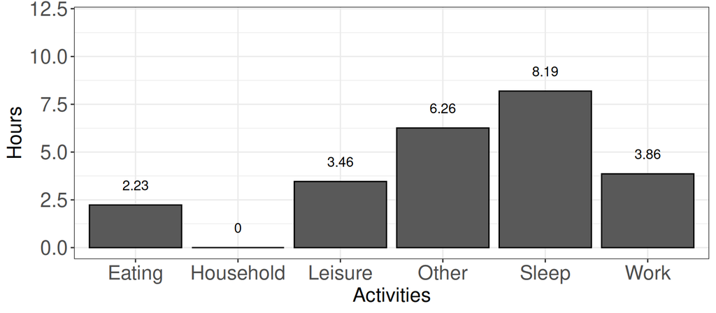

**Answer:** 12.35

**R code:**

```
24 - 8.19 - 3.46
```

The chart below shows how Jessica spends their time in a typical weekday. How many hours in a 24 hour day does Jessica spend doing something other than sleeping or leisure?

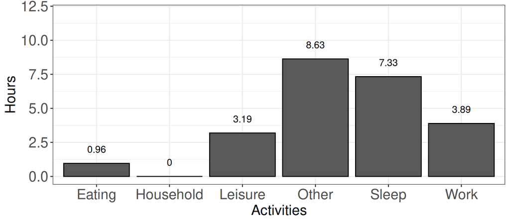

**Answer:** 13.48

**R code:**

```
24 - 7.33 - 3.19
```

The chart below shows how Riley spends their time in a typical weekday. How many hours in a 24 hour day does Riley spend doing something other than sleeping or leisure?

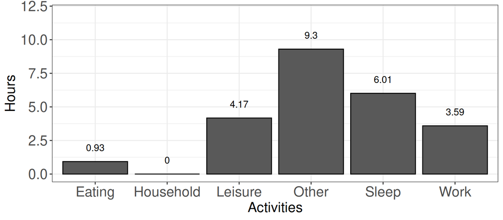

**Answer:** 13.82

**R code:**

```
24 - 6.01 - 4.17
```

The chart below shows how Victoria spends their time in a typical weekday. How many hours in a 24 hour day does Victoria spend doing something other than sleeping or leisure?

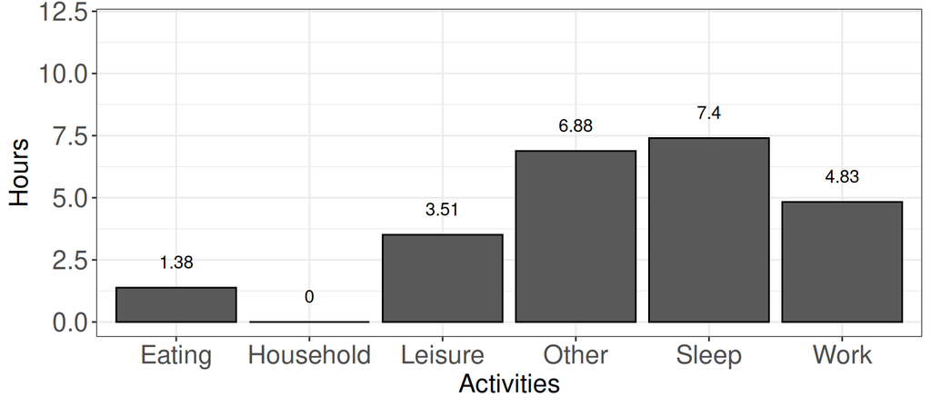

**Answer:** 13.09

**R code:**

```
24 - 7.4 - 3.51
```

The chart below shows how Jarrod spends their time in a typical weekday. How many hours in a 24 hour day does Jarrod spend doing something other than sleeping or leisure?

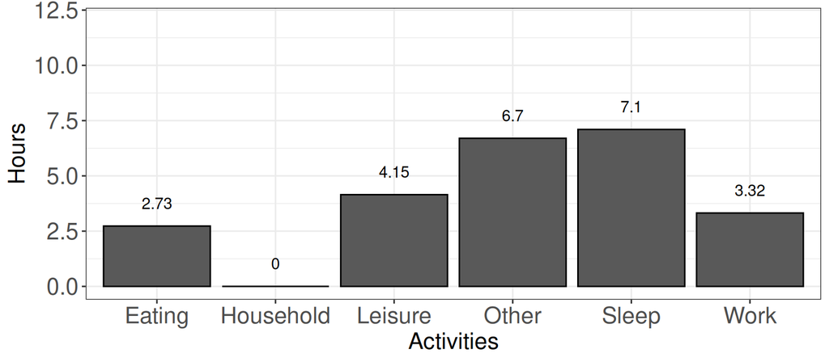

**Answer:** 12.75

**R code:**

```
24 - 7.1 - 4.15
```

The chart below shows how Zakary spends their time in a typical weekday. How many hours in a 24 hour day does Zakary spend doing something other than sleeping or leisure?

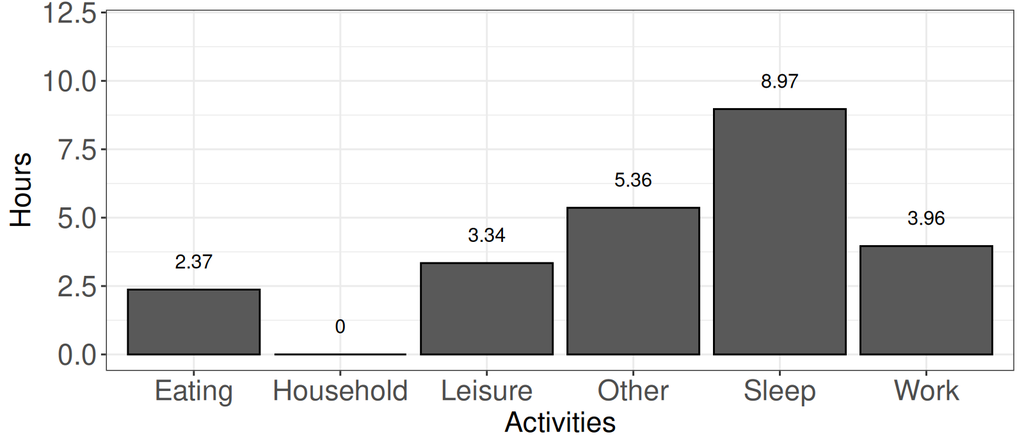

**Answer:** 11.69

**R code:**

```
24 - 8.97 - 3.34
```

The chart below shows how Hayden spends their time in a typical weekday. How many hours in a 24 hour day does Hayden spend doing something other than sleeping or leisure?

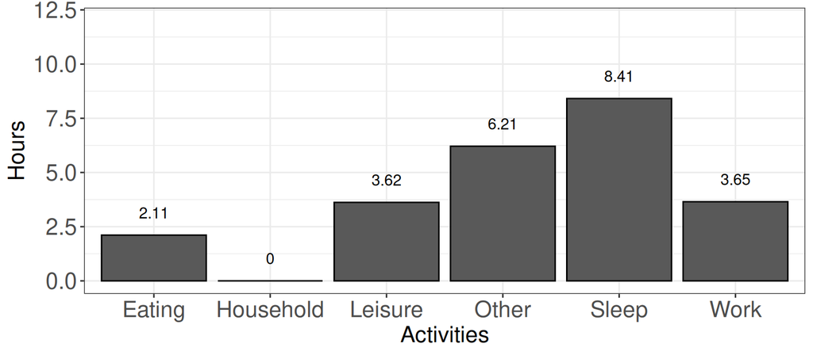

**Answer:** 11.97

**R code:**

```
24 - 8.41 - 3.62
```

Ashley scored the following percentages on her end of the year exams:

- Alchemy: $78.1$
- Astrology: $85.2$
- Falconry: $75$
- Logic: $86.3$
- Music: $94$
- Swordsmanship: $65.6$
- Tarot: $57.7$
- Xylomancy: $81$

What was her mean grade?

**Answer:** 77.8625

**Solution:**

$\frac{78.1 + 85.2 + 75 + 86.3 + 94 + 65.6 +57.7 + 81}{8} = 77.8625$

**R code:**

```
x <- c(78.1, 85.2, 75, 86.3, 94, 65.6, 57.7, 81)

mean(x)
```

Courtney scored the following percentages on her end of the year exams:

- Alchemy: $85.3$
- Astrology: $65.8$
- Falconry: $56.8$
- Logic: $62.8$
- Music: $85.4$
- Swordsmanship: $52.6$
- Tarot: $82.4$
- Xylomancy: $98.8$

What was her mean grade?

**Answer:** 73.7375

**Solution:**

$\frac{85.3 + 65.8 + 56.8 + 62.8 + 85.4 + 52.6 +82.4 + 98.8}{8} = 73.7375$

**R code:**

```
x <- c(85.3, 65.8, 56.8, 62.8, 85.4, 52.6, 82.4, 98.8)

mean(x)
```

Kylie scored the following percentages on her end of the year exams:

- Alchemy: $63.4$
- Astrology: $52.7$
- Falconry: $72.4$
- Logic: $67.4$
- Music: $91.7$
- Swordsmanship: $99.6$
- Tarot: $60.3$
- Xylomancy: $97.3$

What was her mean grade?

**Answer:** 75.6

**Solution:**

$\frac{63.4 + 52.7 + 72.4 + 67.4 + 91.7 + 99.6 +60.3 + 97.3}{8} = 75.6$

**R code:**

```
x <- c(63.4, 52.7, 72.4, 67.4, 91.7, 99.6, 60.3, 97.3)

mean(x)
```

Mary-Morgan scored the following percentages on her end of the year exams:

- Alchemy: $89.9$
- Astrology: $67.4$
- Falconry: $86.5$
- Logic: $81.3$
- Music: $67.9$
- Swordsmanship: $87.4$
- Tarot: $72.4$
- Xylomancy: $55.2$

What was her mean grade?

**Answer:** 76

**Solution:**

$\frac{89.9 + 67.4 + 86.5 + 81.3 + 67.9 + 87.4 +72.4 + 55.2}{8} = 76$

**R code:**

```
x <- c(89.9, 67.4, 86.5, 81.3, 67.9, 87.4, 72.4, 55.2)

mean(x)
```

Samantha scored the following percentages on her end of the year exams:

- Alchemy: $97.8$
- Astrology: $61.9$
- Falconry: $66.9$
- Logic: $53.6$
- Music: $96.8$
- Swordsmanship: $61.2$
- Tarot: $94.2$
- Xylomancy: $83$

What was her mean grade?

**Answer:** 76.925

**Solution:**

$\frac{97.8 + 61.9 + 66.9 + 53.6 + 96.8 + 61.2 +94.2 + 83}{8} = 76.925$

**R code:**

```
x <- c(97.8, 61.9, 66.9, 53.6, 96.8, 61.2, 94.2, 83)

mean(x)
```

Isabel scored the following percentages on her end of the year exams:

- Alchemy: $77.8$
- Astrology: $57$
- Falconry: $93.8$
- Logic: $59.5$
- Music: $98.1$
- Swordsmanship: $55$
- Tarot: $64.6$
- Xylomancy: $66$

What was her mean grade?

**Answer:** 71.475

**Solution:**

$\frac{77.8 + 57 + 93.8 + 59.5 + 98.1 + 55 +64.6 + 66}{8} = 71.475$

**R code:**

```
x <- c(77.8, 57, 93.8, 59.5, 98.1, 55, 64.6, 66)

mean(x)
```

Myriah scored the following percentages on her end of the year exams:

- Alchemy: $60.9$
- Astrology: $92.6$
- Falconry: $74.4$
- Logic: $98.7$
- Music: $92.6$
- Swordsmanship: $74.9$
- Tarot: $79.3$
- Xylomancy: $63$

What was her mean grade?

**Answer:** 79.55

**Solution:**

$\frac{60.9 + 92.6 + 74.4 + 98.7 + 92.6 + 74.9 +79.3 + 63}{8} = 79.55$

**R code:**

```
x <- c(60.9, 92.6, 74.4, 98.7, 92.6, 74.9, 79.3, 63)

mean(x)
```

Tonnica scored the following percentages on her end of the year exams:

- Alchemy: $51.2$
- Astrology: $98.6$
- Falconry: $83.9$
- Logic: $52.8$
- Music: $80.5$
- Swordsmanship: $100$
- Tarot: $57.3$
- Xylomancy: $90.6$

What was her mean grade?

**Answer:** 76.8625

**Solution:**

$\frac{51.2 + 98.6 + 83.9 + 52.8 + 80.5 + 100 +57.3 + 90.6}{8} = 76.8625$

**R code:**

```
x <- c(51.2, 98.6, 83.9, 52.8, 80.5, 100, 57.3, 90.6)

mean(x)
```

Geena scored the following percentages on her end of the year exams:

- Alchemy: $93.6$
- Astrology: $52$
- Falconry: $61.3$
- Logic: $58.1$
- Music: $51.7$
- Swordsmanship: $89.6$
- Tarot: $63.7$
- Xylomancy: $80.9$

What was her mean grade?

**Answer:** 68.8625

**Solution:**

$\frac{93.6 + 52 + 61.3 + 58.1 + 51.7 + 89.6 +63.7 + 80.9}{8} = 68.8625$

**R code:**

```
x <- c(93.6, 52, 61.3, 58.1, 51.7, 89.6, 63.7, 80.9)

mean(x)
```

Chelsea scored the following percentages on her end of the year exams:

- Alchemy: $63.1$
- Astrology: $63.7$
- Falconry: $75.1$
- Logic: $73.7$
- Music: $92.5$
- Swordsmanship: $68.5$
- Tarot: $65.1$
- Xylomancy: $66.3$

What was her mean grade?

**Answer:** 71

**Solution:**

$\frac{63.1 + 63.7 + 75.1 + 73.7 + 92.5 + 68.5 +65.1 + 66.3}{8} = 71$

**R code:**

```
x <- c(63.1, 63.7, 75.1, 73.7, 92.5, 68.5, 65.1, 66.3)

mean(x)
```

Which of the following is a valid way to label a sample mean? Select all that apply. (Note: if it is hard to see the notation, you can zoom in and out on your browser with Ctrl + and Ctrl - respectively)

$\bar{x}$$\hat{y}$$\mu$$\tilde{y}$$\tilde{x}$$\hat{x}$$\sigma$$\bar{y}$

Which of the following is a valid way to label a sample mean? Select all that apply. (Note: if it is hard to see the notation, you can zoom in and out on your browser with Ctrl + and Ctrl - respectively)

$\hat{x}$$\tilde{x}$$\hat{y}$$\bar{y}$$\bar{x}$$\tilde{y}$$\mu$$\sigma$

Which of the following is a valid way to label a sample mean? Select all that apply. (Note: if it is hard to see the notation, you can zoom in and out on your browser with Ctrl + and Ctrl - respectively)

$\bar{x}$$\sigma$$\tilde{y}$$\hat{y}$$\bar{y}$$\tilde{x}$$\hat{x}$$\mu$

Which of the following is a valid way to label a sample mean? Select all that apply. (Note: if it is hard to see the notation, you can zoom in and out on your browser with Ctrl + and Ctrl - respectively)

$\hat{y}$$\bar{y}$$\hat{x}$$\tilde{y}$$\sigma$$\bar{x}$$\mu$$\tilde{x}$

Which of the following is a valid way to label a sample mean? Select all that apply. (Note: if it is hard to see the notation, you can zoom in and out on your browser with Ctrl + and Ctrl - respectively)

$\tilde{y}$$\bar{x}$$\tilde{x}$$\mu$$\bar{y}$$\hat{x}$$\hat{y}$$\sigma$

Which of the following is a valid way to label a sample mean? Select all that apply. (Note: if it is hard to see the notation, you can zoom in and out on your browser with Ctrl + and Ctrl - respectively)

$\mu$$\tilde{y}$$\tilde{x}$$\hat{y}$$\hat{x}$$\bar{x}$$\bar{y}$$\sigma$

Which of the following is a valid way to label a sample mean? Select all that apply. (Note: if it is hard to see the notation, you can zoom in and out on your browser with Ctrl + and Ctrl - respectively)

$\bar{y}$$\sigma$$\tilde{x}$$\mu$$\tilde{y}$$\hat{y}$$\bar{x}$$\hat{x}$

Which of the following is a valid way to label a sample mean? Select all that apply. (Note: if it is hard to see the notation, you can zoom in and out on your browser with Ctrl + and Ctrl - respectively)

$\tilde{x}$$\sigma$$\bar{x}$$\tilde{y}$$\hat{y}$$\hat{x}$$\mu$$\bar{y}$

Which of the following is a valid way to label a sample mean? Select all that apply. (Note: if it is hard to see the notation, you can zoom in and out on your browser with Ctrl + and Ctrl - respectively)

$\hat{x}$$\bar{x}$$\bar{y}$$\sigma$$\tilde{y}$$\tilde{x}$$\mu$$\hat{y}$

Which of the following is a valid way to label a sample mean? Select all that apply. (Note: if it is hard to see the notation, you can zoom in and out on your browser with Ctrl + and Ctrl - respectively)

$\mu$$\bar{y}$$\hat{x}$$\tilde{y}$$\bar{x}$$\hat{y}$$\tilde{x}$$\sigma$

What happens to the mean of the values below if 100 is added to each of them?

-74.9, -34.4, -27.1, -101, -3.9, -81.6, -74.3, -67.2, -60.8, -13, -37.8, -47.8, -93.9, 14.7, -87, -52.1, -41.5, -89.7, -92.8, -84.5, -64.4, -72.5, -130.8, -93.7

The mean has 100 added to itThe mean is divided by 100The mean stays the sameThe mean is multiplied by 100The mean has 100 subtracted from it

**R code:**

```
x <- c(-74.9, -34.4, -27.1, -101, -3.9, -81.6, -74.3, -67.2, -60.8, -13, -37.8, -47.8, -93.9, 14.7, -87, -52.1, -41.5, -89.7, -92.8, -84.5, -64.4, -72.5, -130.8, -93.7)

mean(x) # original mean
mean(x + 100) # new mean

mean(x + 100) - mean(x)
```

What happens to the mean of the values below if 100 is added to each of them?

87.6, 117.3, 213, 74.8, 11, -18.2, 71.1, -32.7, -25.8, 74.4, 43.5, 86.6, 69, 55.8, 124.3, -50.4, 92.3, 44.7, -8.8, -24.7, 258, 14.5, -28.4, 110, 29.4, 30, -54.3, 18.6, 47.4

The mean is multiplied by 100The mean has 100 added to itThe mean stays the sameThe mean has 100 subtracted from itThe mean is divided by 100

**R code:**

```
x <- c(87.6, 117.3, 213, 74.8, 11, -18.2, 71.1, -32.7, -25.8, 74.4, 43.5, 86.6, 69, 55.8, 124.3, -50.4, 92.3, 44.7, -8.8, -24.7, 258, 14.5, -28.4, 110, 29.4, 30, -54.3, 18.6, 47.4)

mean(x) # original mean
mean(x + 100) # new mean

mean(x + 100) - mean(x)
```

What happens to the mean of the values below if 100 is added to each of them?

132.6, -85.5, -212.4, 74.6, 109.9, 49.5, 13.9, -73.1, -34.6, -56.5, 80.9, 212.7, 4.1, 185.7, 40.8, 20, -313.1, -10.1, 120.1, -67.9, 164.8, 25.9, -56.1, -53.9

The mean is multiplied by 100The mean is divided by 100The mean has 100 subtracted from itThe mean has 100 added to itThe mean stays the same

**R code:**

```
x <- c(132.6, -85.5, -212.4, 74.6, 109.9, 49.5, 13.9, -73.1, -34.6, -56.5, 80.9, 212.7, 4.1, 185.7, 40.8, 20, -313.1, -10.1, 120.1, -67.9, 164.8, 25.9, -56.1, -53.9)

mean(x) # original mean
mean(x + 100) # new mean

mean(x + 100) - mean(x)
```

What happens to the mean of the values below if 100 is added to each of them?

-45.9, -25.2, -8.5, 4.2, -22.4, -50.3, -29, -40.9, -28.3, -48.7, -26.4, -30.2, -22.8, -33.2, -67.2, -43.6, -60.7, -48.3, -113.8, -27.3, -3, -27.3

The mean is multiplied by 100The mean stays the sameThe mean is divided by 100The mean has 100 subtracted from itThe mean has 100 added to it

**R code:**

```
x <- c(-45.9, -25.2, -8.5, 4.2, -22.4, -50.3, -29, -40.9, -28.3, -48.7, -26.4, -30.2, -22.8, -33.2, -67.2, -43.6, -60.7, -48.3, -113.8, -27.3, -3, -27.3)

mean(x) # original mean
mean(x + 100) # new mean

mean(x + 100) - mean(x)
```

What happens to the mean of the values below if 100 is added to each of them?

-56.3, -33.1, -74.3, -36.9, -60.2, -10.6, -51.4, -27.2, -35.6, -66.3, -34.2, -77.3, -45.7, -58.1, -49.3, -81.5, -33.4, -92.5, -54.7, -65.1, -30.3, -44.4, -76.7, -63.4, -42.1, -90

The mean is divided by 100The mean is multiplied by 100The mean has 100 subtracted from itThe mean has 100 added to itThe mean stays the same

**R code:**

```
x <- c(-56.3, -33.1, -74.3, -36.9, -60.2, -10.6, -51.4, -27.2, -35.6, -66.3, -34.2, -77.3, -45.7, -58.1, -49.3, -81.5, -33.4, -92.5, -54.7, -65.1, -30.3, -44.4, -76.7, -63.4, -42.1, -90)

mean(x) # original mean
mean(x + 100) # new mean

mean(x + 100) - mean(x)
```

What happens to the mean of the values below if 100 is added to each of them?

56.9, 42, 56.3, 48.9, 73.6, 63.8, 65.6, 63.5, 48.5, 60.1, 53, 63.9, 54.1, 48, 65.6, 43.8, 55.5, 65, 68.6, 43.5, 65.1, 55.8, 73.8, 43.2, 56.3, 56.1, 54.1, 54.5, 71.4

The mean has 100 subtracted from itThe mean has 100 added to itThe mean stays the sameThe mean is divided by 100The mean is multiplied by 100

**R code:**

```
x <- c(56.9, 42, 56.3, 48.9, 73.6, 63.8, 65.6, 63.5, 48.5, 60.1, 53, 63.9, 54.1, 48, 65.6, 43.8, 55.5, 65, 68.6, 43.5, 65.1, 55.8, 73.8, 43.2, 56.3, 56.1, 54.1, 54.5, 71.4)

mean(x) # original mean
mean(x + 100) # new mean

mean(x + 100) - mean(x)
```

What happens to the mean of the values below if 100 is added to each of them?

-0.5, 22.1, -115.8, -23.2, 31.8, 48.8, 36.4, -34.8, 19, -106.9, 24.5, -43.4, 30.2, 37.4, -65.5, -35.3, -14.5, -10.7, -59.2, -28.9

The mean is multiplied by 100The mean has 100 subtracted from itThe mean is divided by 100The mean stays the sameThe mean has 100 added to it

**R code:**

```
x <- c(-0.5, 22.1, -115.8, -23.2, 31.8, 48.8, 36.4, -34.8, 19, -106.9, 24.5, -43.4, 30.2, 37.4, -65.5, -35.3, -14.5, -10.7, -59.2, -28.9)

mean(x) # original mean
mean(x + 100) # new mean

mean(x + 100) - mean(x)
```

What happens to the mean of the values below if 100 is added to each of them?

98.2, -75.3, -3.3, -96.8, -99.6, 35.6, -210.8, -164.9, -82.8, -151, -214.7, -22.8, -150.9, -109.9, -19.9, -77.9, -98.9, -182.7, 28.9, -202.1, -197.4, -66.2, -32.6, -52.7, -180.3, -145.4, -119.6, -101.9

The mean is divided by 100The mean has 100 subtracted from itThe mean stays the sameThe mean has 100 added to itThe mean is multiplied by 100

**R code:**

```
x <- c(98.2, -75.3, -3.3, -96.8, -99.6, 35.6, -210.8, -164.9, -82.8, -151, -214.7, -22.8, -150.9, -109.9, -19.9, -77.9, -98.9, -182.7, 28.9, -202.1, -197.4, -66.2, -32.6, -52.7, -180.3, -145.4, -119.6, -101.9)

mean(x) # original mean
mean(x + 100) # new mean

mean(x + 100) - mean(x)
```

What happens to the mean of the values below if 100 is added to each of them?

41.4, 73.1, 38, 81.3, 67.6, 117.3, 61.9, 55, 34.8, 132.5, -25.7, 55.2, 37.1, 158.1, 69.4, 142.4, 66.9, 113.8, 43.8, 64.1, 116.3, 130.8, 4.3, 7.1, 89.8, 40.1

The mean has 100 added to itThe mean is divided by 100The mean stays the sameThe mean has 100 subtracted from itThe mean is multiplied by 100

**R code:**

```
x <- c(41.4, 73.1, 38, 81.3, 67.6, 117.3, 61.9, 55, 34.8, 132.5, -25.7, 55.2, 37.1, 158.1, 69.4, 142.4, 66.9, 113.8, 43.8, 64.1, 116.3, 130.8, 4.3, 7.1, 89.8, 40.1)

mean(x) # original mean
mean(x + 100) # new mean

mean(x + 100) - mean(x)
```

What happens to the mean of the values below if 100 is added to each of them?

10.4, 147, 36.9, 55, -56.1, 9.8, -26.5, 57.5, 33, 2.8, 57.1, -72.7, -5.2, 0.1, 70.2, 5.4, -94.7, -81.5, 17.1, 29.5, 50.1, -33, -64, -98.9, -121.9, 24.7

The mean has 100 subtracted from itThe mean has 100 added to itThe mean is multiplied by 100The mean is divided by 100The mean stays the same

**R code:**

```
x <- c(10.4, 147, 36.9, 55, -56.1, 9.8, -26.5, 57.5, 33, 2.8, 57.1, -72.7, -5.2, 0.1, 70.2, 5.4, -94.7, -81.5, 17.1, 29.5, 50.1, -33, -64, -98.9, -121.9, 24.7)

mean(x) # original mean
mean(x + 100) # new mean

mean(x + 100) - mean(x)
```

What happens to the mean of the values below if each is multiplied by 100?

74.8, 74.6, 164.9, 104.3, 44.5, 124, 100.7, 87.5, 102.4, 142.3, 160.8, 104.4, 63.1, 52.1, 79.1, 101.6, 150.4, 154.4, 87.9, 67.1, -7.8, 121, 58.1, 131.2, 63.7, 88.9, 124.5, 156.7

The mean is multiplied by 100The mean stays the sameThe mean has 100 added to itThe mean is divided by 100The mean has 100 subtracted from it

**R code:**

```
x <- c(74.8, 74.6, 164.9, 104.3, 44.5, 124, 100.7, 87.5, 102.4, 142.3, 160.8, 104.4, 63.1, 52.1, 79.1, 101.6, 150.4, 154.4, 87.9, 67.1, -7.8, 121, 58.1, 131.2, 63.7, 88.9, 124.5, 156.7)

mean(x) # original mean
mean(x * 100) # new mean

mean(x) * 100
```

What happens to the mean of the values below if each is multiplied by 100?

53.1, -34.5, 169.5, -50.6, 101.3, -23.7, 7.4, 74.9, -26.8, 38.7, -94.3, 187.7, 61.6, -117.4, -121.8, 51.8, 28.2, 23.2, 31, -20.3, -99.7, 44.7, 14.6, -97.8, 68.7, 93, 9.4

The mean is multiplied by 100The mean is divided by 100The mean stays the sameThe mean has 100 added to itThe mean has 100 subtracted from it

**R code:**

```
x <- c(53.1, -34.5, 169.5, -50.6, 101.3, -23.7, 7.4, 74.9, -26.8, 38.7, -94.3, 187.7, 61.6, -117.4, -121.8, 51.8, 28.2, 23.2, 31, -20.3, -99.7, 44.7, 14.6, -97.8, 68.7, 93, 9.4)

mean(x) # original mean
mean(x * 100) # new mean

mean(x) * 100
```

What happens to the mean of the values below if each is multiplied by 100?

-6.9, 1.4, 0.6, -8.7, 45.9, 43.6, 63.8, 95.9, 112.7, 54.6, 34.6, 75.6, 99.3, 108.8, 100.4, 67.2, 64.2, 84.8, 100, 121.9, 42.3

The mean is divided by 100The mean has 100 subtracted from itThe mean has 100 added to itThe mean is multiplied by 100The mean stays the same

**R code:**

```
x <- c(-6.9, 1.4, 0.6, -8.7, 45.9, 43.6, 63.8, 95.9, 112.7, 54.6, 34.6, 75.6, 99.3, 108.8, 100.4, 67.2, 64.2, 84.8, 100, 121.9, 42.3)

mean(x) # original mean
mean(x * 100) # new mean

mean(x) * 100
```

What happens to the mean of the values below if each is multiplied by 100?

-27.6, 13.4, 13.1, -26.4, 51.5, 26, 15.1, 12.2, -29.1, 38.3, -17.6, -1.2, 76.5, -0.9, 88.4, -8.5, 35.9, -67.1, 67.5, -56.3, -15, 29.7, -5.4, -40.2, -53.7, -14.1

The mean has 100 subtracted from itThe mean has 100 added to itThe mean is divided by 100The mean is multiplied by 100The mean stays the same

**R code:**

```
x <- c(-27.6, 13.4, 13.1, -26.4, 51.5, 26, 15.1, 12.2, -29.1, 38.3, -17.6, -1.2, 76.5, -0.9, 88.4, -8.5, 35.9, -67.1, 67.5, -56.3, -15, 29.7, -5.4, -40.2, -53.7, -14.1)

mean(x) # original mean
mean(x * 100) # new mean

mean(x) * 100
```

What happens to the mean of the values below if each is multiplied by 100?

-107, -176, -76, -192.4, -101.4, -73.2, -85.3, -104.5, -99, -158.6, -174.7, -164.8, -191.8, -42, -67.4, -218.4, -46.1, -94.5, -68, -97.5, -134.2, -88.3, -80.9

The mean is divided by 100The mean has 100 added to itThe mean stays the sameThe mean is multiplied by 100The mean has 100 subtracted from it

**R code:**

```
x <- c(-107, -176, -76, -192.4, -101.4, -73.2, -85.3, -104.5, -99, -158.6, -174.7, -164.8, -191.8, -42, -67.4, -218.4, -46.1, -94.5, -68, -97.5, -134.2, -88.3, -80.9)

mean(x) # original mean
mean(x * 100) # new mean

mean(x) * 100
```

What happens to the mean of the values below if each is multiplied by 100?

132.4, 117.1, 168.8, 124, 195.9, 97.9, 51.9, -13.6, 36.5, 56, -121.3, 120.4, 216.9, 108.5, 134.5, 166.1, -168.1, 133.5, 68.3, 3.4, -100.7, 117.3

The mean is multiplied by 100The mean has 100 added to itThe mean has 100 subtracted from itThe mean stays the sameThe mean is divided by 100

**R code:**

```
x <- c(132.4, 117.1, 168.8, 124, 195.9, 97.9, 51.9, -13.6, 36.5, 56, -121.3, 120.4, 216.9, 108.5, 134.5, 166.1, -168.1, 133.5, 68.3, 3.4, -100.7, 117.3)

mean(x) # original mean
mean(x * 100) # new mean

mean(x) * 100
```

What happens to the mean of the values below if each is multiplied by 100?

23.7, 27.3, 18.5, 44.3, 49, 27.3, 16.7, 23.1, 31.8, 2.9, 35.9, 21.5, 14, 46.9, 68.9, 52.9, 22.4, 13.8, 54, 31.9, 15, 23.4, 36.2

The mean is multiplied by 100The mean has 100 added to itThe mean is divided by 100The mean has 100 subtracted from itThe mean stays the same

**R code:**

```
x <- c(23.7, 27.3, 18.5, 44.3, 49, 27.3, 16.7, 23.1, 31.8, 2.9, 35.9, 21.5, 14, 46.9, 68.9, 52.9, 22.4, 13.8, 54, 31.9, 15, 23.4, 36.2)

mean(x) # original mean
mean(x * 100) # new mean

mean(x) * 100
```

What happens to the mean of the values below if each is multiplied by 100?

-65.5, -78.5, -12.5, -64.6, -10.8, -49.7, -34.7, -68.9, -81.8, 42.1, -100.7, -39, 0.3, -39.3, -57.4, -91.7, -37.4, -31.8, 21.1, -53, -44.1, -7.3, -42.8

The mean has 100 added to itThe mean is divided by 100The mean stays the sameThe mean has 100 subtracted from itThe mean is multiplied by 100

**R code:**

```
x <- c(-65.5, -78.5, -12.5, -64.6, -10.8, -49.7, -34.7, -68.9, -81.8, 42.1, -100.7, -39, 0.3, -39.3, -57.4, -91.7, -37.4, -31.8, 21.1, -53, -44.1, -7.3, -42.8)

mean(x) # original mean
mean(x * 100) # new mean

mean(x) * 100
```

What happens to the mean of the values below if each is multiplied by 100?

90.1, 91.6, 50.6, -14.4, 120.7, 22.7, 71.8, 55.1, 79.4, 27.7, 14.3, -26.1, 55, 18.9, 69.1, -13.7, 27.8, 100.9, 91.8, 49.5, 99.1, 197.8, 104.3, 16, 37, 94.7, 46.3, 65

The mean is divided by 100The mean has 100 added to itThe mean has 100 subtracted from itThe mean stays the sameThe mean is multiplied by 100

**R code:**

```
x <- c(90.1, 91.6, 50.6, -14.4, 120.7, 22.7, 71.8, 55.1, 79.4, 27.7, 14.3, -26.1, 55, 18.9, 69.1, -13.7, 27.8, 100.9, 91.8, 49.5, 99.1, 197.8, 104.3, 16, 37, 94.7, 46.3, 65)

mean(x) # original mean
mean(x * 100) # new mean

mean(x) * 100
```

What happens to the mean of the values below if each is multiplied by 100?

-10.8, -8.3, -4.1, -15.7, 69.3, 23.5, -15.8, 1.2, 61.2, -34.8, 9.4, 30.5, 5.1, 13.9, 15.3, -2.6, -17, -34.1, -21.1, -28.1, -24.4, 44.1, -83.2, -25.5

The mean is multiplied by 100The mean has 100 subtracted from itThe mean is divided by 100The mean has 100 added to itThe mean stays the same

**R code:**

```
x <- c(-10.8, -8.3, -4.1, -15.7, 69.3, 23.5, -15.8, 1.2, 61.2, -34.8, 9.4, 30.5, 5.1, 13.9, 15.3, -2.6, -17, -34.1, -21.1, -28.1, -24.4, 44.1, -83.2, -25.5)

mean(x) # original mean
mean(x * 100) # new mean

mean(x) * 100
```

A researcher had five different groups of rats in an experiment. Each group of rats was given a different dosage of caffeine. The number of rats in each group and their dosage in milligrams (mg) is below. What was the average dose of caffeine across all the rats?

| Group | Rats | Dose |
| --- | --- | --- |
| Control | 11 | 0 |
| A | 12 | 4 |
| B | 8 | 8 |
| C | 14 | 16 |
| D | 7 | 32 |

To make your life easier, you might want to read up on weighted means:

https://www.mathsisfun.com/data/weighted-mean.html

**Answer:** 10.7692308

**Solution:**

*Using a Weighted Mean:*

$\frac{11 \times 0 + 12 \times 4 + 8 \times 8 + 14 \times 16 + 7 \times 32} {11 + 12 + 8 + 14 + 7} = \frac{560}{52} = 10.769$

*Using the Conventional Mean:*

$\frac{0+0+0+0+0+0+0+0+0+0+0+4+4+4+4+4+4+4+4+4+4+4+4+8+8+8+8+8+8+8+8+16+16+16+16+16+16+16+16+16+16+16+16+16+16+32+32+32+32+32+32+32}{52} = \frac{560}{52} = 10.769$

**R code:**

```
x <- c(0, 4, 8, 16, 32) # values to average
w <- c(11, 12, 8, 14, 7) # weights

sum(x * w) / sum(w)
```

A researcher had five different groups of rats in an experiment. Each group of rats was given a different dosage of caffeine. The number of rats in each group and their dosage in milligrams (mg) is below. What was the average dose of caffeine across all the rats?

| Group | Rats | Dose |
| --- | --- | --- |
| Control | 8 | 0 |
| A | 10 | 4 |
| B | 13 | 8 |
| C | 12 | 16 |
| D | 7 | 32 |

To make your life easier, you might want to read up on weighted means:

https://www.mathsisfun.com/data/weighted-mean.html

**Answer:** 11.2

**Solution:**

*Using a Weighted Mean:*

$\frac{8 \times 0 + 10 \times 4 + 13 \times 8 + 12 \times 16 + 7 \times 32} {8 + 10 + 13 + 12 + 7} = \frac{560}{50} = 11.2$

*Using the Conventional Mean:*

$\frac{0+0+0+0+0+0+0+0+4+4+4+4+4+4+4+4+4+4+8+8+8+8+8+8+8+8+8+8+8+8+8+16+16+16+16+16+16+16+16+16+16+16+16+32+32+32+32+32+32+32}{50} = \frac{560}{50} = 11.2$

**R code:**

```
x <- c(0, 4, 8, 16, 32) # values to average
w <- c(8, 10, 13, 12, 7) # weights

sum(x * w) / sum(w)
```

A researcher had five different groups of rats in an experiment. Each group of rats was given a different dosage of caffeine. The number of rats in each group and their dosage in milligrams (mg) is below. What was the average dose of caffeine across all the rats?

| Group | Rats | Dose |
| --- | --- | --- |
| Control | 7 | 0 |
| A | 9 | 4 |
| B | 6 | 8 |
| C | 10 | 16 |
| D | 11 | 32 |

To make your life easier, you might want to read up on weighted means:

https://www.mathsisfun.com/data/weighted-mean.html

**Answer:** 13.8604651

**Solution:**

*Using a Weighted Mean:*

$\frac{7 \times 0 + 9 \times 4 + 6 \times 8 + 10 \times 16 + 11 \times 32} {7 + 9 + 6 + 10 + 11} = \frac{596}{43} = 13.86$

*Using the Conventional Mean:*

$\frac{0+0+0+0+0+0+0+4+4+4+4+4+4+4+4+4+8+8+8+8+8+8+16+16+16+16+16+16+16+16+16+16+32+32+32+32+32+32+32+32+32+32+32}{43} = \frac{596}{43} = 13.86$

**R code:**

```
x <- c(0, 4, 8, 16, 32) # values to average
w <- c(7, 9, 6, 10, 11) # weights

sum(x * w) / sum(w)
```

A researcher had five different groups of rats in an experiment. Each group of rats was given a different dosage of caffeine. The number of rats in each group and their dosage in milligrams (mg) is below. What was the average dose of caffeine across all the rats?

| Group | Rats | Dose |
| --- | --- | --- |
| Control | 12 | 0 |
| A | 5 | 4 |
| B | 11 | 8 |
| C | 7 | 16 |
| D | 15 | 32 |

To make your life easier, you might want to read up on weighted means:

https://www.mathsisfun.com/data/weighted-mean.html

**Answer:** 14

**Solution:**

*Using a Weighted Mean:*

$\frac{12 \times 0 + 5 \times 4 + 11 \times 8 + 7 \times 16 + 15 \times 32} {12 + 5 + 11 + 7 + 15} = \frac{700}{50} = 14$

*Using the Conventional Mean:*

$\frac{0+0+0+0+0+0+0+0+0+0+0+0+4+4+4+4+4+8+8+8+8+8+8+8+8+8+8+8+16+16+16+16+16+16+16+32+32+32+32+32+32+32+32+32+32+32+32+32+32+32}{50} = \frac{700}{50} = 14$

**R code:**

```
x <- c(0, 4, 8, 16, 32) # values to average
w <- c(12, 5, 11, 7, 15) # weights

sum(x * w) / sum(w)
```

A researcher had five different groups of rats in an experiment. Each group of rats was given a different dosage of caffeine. The number of rats in each group and their dosage in milligrams (mg) is below. What was the average dose of caffeine across all the rats?

| Group | Rats | Dose |
| --- | --- | --- |
| Control | 11 | 0 |
| A | 9 | 4 |
| B | 12 | 8 |
| C | 10 | 16 |
| D | 13 | 32 |

To make your life easier, you might want to read up on weighted means:

https://www.mathsisfun.com/data/weighted-mean.html

**Answer:** 12.8727273

**Solution:**

*Using a Weighted Mean:*

$\frac{11 \times 0 + 9 \times 4 + 12 \times 8 + 10 \times 16 + 13 \times 32} {11 + 9 + 12 + 10 + 13} = \frac{708}{55} = 12.873$

*Using the Conventional Mean:*

$\frac{0+0+0+0+0+0+0+0+0+0+0+4+4+4+4+4+4+4+4+4+8+8+8+8+8+8+8+8+8+8+8+8+16+16+16+16+16+16+16+16+16+16+32+32+32+32+32+32+32+32+32+32+32+32+32}{55} = \frac{708}{55} = 12.873$

**R code:**

```
x <- c(0, 4, 8, 16, 32) # values to average
w <- c(11, 9, 12, 10, 13) # weights

sum(x * w) / sum(w)
```

A researcher had five different groups of rats in an experiment. Each group of rats was given a different dosage of caffeine. The number of rats in each group and their dosage in milligrams (mg) is below. What was the average dose of caffeine across all the rats?

| Group | Rats | Dose |
| --- | --- | --- |
| Control | 15 | 0 |
| A | 10 | 4 |
| B | 11 | 8 |
| C | 7 | 16 |
| D | 13 | 32 |

To make your life easier, you might want to read up on weighted means:

https://www.mathsisfun.com/data/weighted-mean.html

**Answer:** 11.7142857

**Solution:**

*Using a Weighted Mean:*

$\frac{15 \times 0 + 10 \times 4 + 11 \times 8 + 7 \times 16 + 13 \times 32} {15 + 10 + 11 + 7 + 13} = \frac{656}{56} = 11.714$

*Using the Conventional Mean:*

$\frac{0+0+0+0+0+0+0+0+0+0+0+0+0+0+0+4+4+4+4+4+4+4+4+4+4+8+8+8+8+8+8+8+8+8+8+8+16+16+16+16+16+16+16+32+32+32+32+32+32+32+32+32+32+32+32+32}{56} = \frac{656}{56} = 11.714$

**R code:**

```
x <- c(0, 4, 8, 16, 32) # values to average
w <- c(15, 10, 11, 7, 13) # weights

sum(x * w) / sum(w)
```

A researcher had five different groups of rats in an experiment. Each group of rats was given a different dosage of caffeine. The number of rats in each group and their dosage in milligrams (mg) is below. What was the average dose of caffeine across all the rats?

| Group | Rats | Dose |
| --- | --- | --- |
| Control | 10 | 0 |
| A | 13 | 4 |
| B | 6 | 8 |
| C | 8 | 16 |
| D | 15 | 32 |

To make your life easier, you might want to read up on weighted means:

https://www.mathsisfun.com/data/weighted-mean.html

**Answer:** 13.6153846

**Solution:**

*Using a Weighted Mean:*

$\frac{10 \times 0 + 13 \times 4 + 6 \times 8 + 8 \times 16 + 15 \times 32} {10 + 13 + 6 + 8 + 15} = \frac{708}{52} = 13.615$

*Using the Conventional Mean:*

$\frac{0+0+0+0+0+0+0+0+0+0+4+4+4+4+4+4+4+4+4+4+4+4+4+8+8+8+8+8+8+16+16+16+16+16+16+16+16+32+32+32+32+32+32+32+32+32+32+32+32+32+32+32}{52} = \frac{708}{52} = 13.615$

**R code:**

```
x <- c(0, 4, 8, 16, 32) # values to average
w <- c(10, 13, 6, 8, 15) # weights

sum(x * w) / sum(w)
```

A researcher had five different groups of rats in an experiment. Each group of rats was given a different dosage of caffeine. The number of rats in each group and their dosage in milligrams (mg) is below. What was the average dose of caffeine across all the rats?

| Group | Rats | Dose |
| --- | --- | --- |
| Control | 6 | 0 |
| A | 13 | 4 |
| B | 15 | 8 |
| C | 8 | 16 |
| D | 10 | 32 |

To make your life easier, you might want to read up on weighted means:

https://www.mathsisfun.com/data/weighted-mean.html

**Answer:** 11.9230769

**Solution:**

*Using a Weighted Mean:*

$\frac{6 \times 0 + 13 \times 4 + 15 \times 8 + 8 \times 16 + 10 \times 32} {6 + 13 + 15 + 8 + 10} = \frac{620}{52} = 11.923$

*Using the Conventional Mean:*

$\frac{0+0+0+0+0+0+4+4+4+4+4+4+4+4+4+4+4+4+4+8+8+8+8+8+8+8+8+8+8+8+8+8+8+8+16+16+16+16+16+16+16+16+32+32+32+32+32+32+32+32+32+32}{52} = \frac{620}{52} = 11.923$

**R code:**

```
x <- c(0, 4, 8, 16, 32) # values to average
w <- c(6, 13, 15, 8, 10) # weights

sum(x * w) / sum(w)
```

A researcher had five different groups of rats in an experiment. Each group of rats was given a different dosage of caffeine. The number of rats in each group and their dosage in milligrams (mg) is below. What was the average dose of caffeine across all the rats?

| Group | Rats | Dose |
| --- | --- | --- |
| Control | 7 | 0 |
| A | 15 | 4 |
| B | 8 | 8 |
| C | 10 | 16 |
| D | 12 | 32 |

To make your life easier, you might want to read up on weighted means:

https://www.mathsisfun.com/data/weighted-mean.html

**Answer:** 12.8461538

**Solution:**

*Using a Weighted Mean:*

$\frac{7 \times 0 + 15 \times 4 + 8 \times 8 + 10 \times 16 + 12 \times 32} {7 + 15 + 8 + 10 + 12} = \frac{668}{52} = 12.846$

*Using the Conventional Mean:*

$\frac{0+0+0+0+0+0+0+4+4+4+4+4+4+4+4+4+4+4+4+4+4+4+8+8+8+8+8+8+8+8+16+16+16+16+16+16+16+16+16+16+32+32+32+32+32+32+32+32+32+32+32+32}{52} = \frac{668}{52} = 12.846$

**R code:**

```
x <- c(0, 4, 8, 16, 32) # values to average
w <- c(7, 15, 8, 10, 12) # weights

sum(x * w) / sum(w)
```

A researcher had five different groups of rats in an experiment. Each group of rats was given a different dosage of caffeine. The number of rats in each group and their dosage in milligrams (mg) is below. What was the average dose of caffeine across all the rats?

| Group | Rats | Dose |
| --- | --- | --- |
| Control | 5 | 0 |
| A | 6 | 4 |
| B | 11 | 8 |
| C | 12 | 16 |
| D | 14 | 32 |

To make your life easier, you might want to read up on weighted means:

https://www.mathsisfun.com/data/weighted-mean.html

**Answer:** 15.6666667

**Solution:**

*Using a Weighted Mean:*

$\frac{5 \times 0 + 6 \times 4 + 11 \times 8 + 12 \times 16 + 14 \times 32} {5 + 6 + 11 + 12 + 14} = \frac{752}{48} = 15.667$

*Using the Conventional Mean:*

$\frac{0+0+0+0+0+4+4+4+4+4+4+8+8+8+8+8+8+8+8+8+8+8+16+16+16+16+16+16+16+16+16+16+16+16+32+32+32+32+32+32+32+32+32+32+32+32+32+32}{48} = \frac{752}{48} = 15.667$

**R code:**

```
x <- c(0, 4, 8, 16, 32) # values to average
w <- c(5, 6, 11, 12, 14) # weights

sum(x * w) / sum(w)
```

Suppose there are 58 people in a room and the mean amount of cash held by these 58 people is $9.88 per person. If two people enter the room carrying $5.09 and $8.25 respectively, what does the mean amount of cash in the room become?

**Answer:** 9.773

**Solution:**

The basic solution is to use a weighted mean.

$\frac{5.09 \times 1 + 8.25 \times 1 + 9.88 \times 58}{1 + 1 + 58} = 9.773$

**R code:**

```
x <- c(5.09, 8.25, 9.88)
w <- c(1, 1, 58)
sum(x * w) / sum(w)
```

Suppose there are 68 people in a room and the mean amount of cash held by these 68 people is $9.53 per person. If two people enter the room carrying $5.45 and $7.41 respectively, what does the mean amount of cash in the room become?

**Answer:** 9.4414286

**Solution:**

The basic solution is to use a weighted mean.

$\frac{5.45 \times 1 + 7.41 \times 1 + 9.53 \times 68}{1 + 1 + 68} = 9.4414286$

**R code:**

```
x <- c(5.45, 7.41, 9.53)
w <- c(1, 1, 68)
sum(x * w) / sum(w)
```

Suppose there are 63 people in a room and the mean amount of cash held by these 63 people is $9.6 per person. If two people enter the room carrying $4.72 and $4.14 respectively, what does the mean amount of cash in the room become?

**Answer:** 9.4409231

**Solution:**

The basic solution is to use a weighted mean.

$\frac{4.72 \times 1 + 4.14 \times 1 + 9.6 \times 63}{1 + 1 + 63} = 9.4409231$

**R code:**

```
x <- c(4.72, 4.14, 9.6)
w <- c(1, 1, 63)
sum(x * w) / sum(w)
```

Suppose there are 62 people in a room and the mean amount of cash held by these 62 people is $8.55 per person. If two people enter the room carrying $8.38 and $9.71 respectively, what does the mean amount of cash in the room become?

**Answer:** 8.5654688

**Solution:**

The basic solution is to use a weighted mean.

$\frac{8.38 \times 1 + 9.71 \times 1 + 8.55 \times 62}{1 + 1 + 62} = 8.5654688$

**R code:**

```
x <- c(8.38, 9.71, 8.55)
w <- c(1, 1, 62)
sum(x * w) / sum(w)
```

Suppose there are 62 people in a room and the mean amount of cash held by these 62 people is $6.19 per person. If two people enter the room carrying $6.59 and $5.87 respectively, what does the mean amount of cash in the room become?

**Answer:** 6.19125

**Solution:**

The basic solution is to use a weighted mean.

$\frac{6.59 \times 1 + 5.87 \times 1 + 6.19 \times 62}{1 + 1 + 62} = 6.19125$

**R code:**

```
x <- c(6.59, 5.87, 6.19)
w <- c(1, 1, 62)
sum(x * w) / sum(w)
```

Suppose there are 64 people in a room and the mean amount of cash held by these 64 people is $4.71 per person. If two people enter the room carrying $9.38 and $8.82 respectively, what does the mean amount of cash in the room become?

**Answer:** 4.8430303

**Solution:**

The basic solution is to use a weighted mean.

$\frac{9.38 \times 1 + 8.82 \times 1 + 4.71 \times 64}{1 + 1 + 64} = 4.8430303$

**R code:**

```
x <- c(9.38, 8.82, 4.71)
w <- c(1, 1, 64)
sum(x * w) / sum(w)
```

Suppose there are 42 people in a room and the mean amount of cash held by these 42 people is $7.46 per person. If two people enter the room carrying $7.41 and $8.17 respectively, what does the mean amount of cash in the room become?

**Answer:** 7.475

**Solution:**

The basic solution is to use a weighted mean.

$\frac{7.41 \times 1 + 8.17 \times 1 + 7.46 \times 42}{1 + 1 + 42} = 7.475$

**R code:**

```
x <- c(7.41, 8.17, 7.46)
w <- c(1, 1, 42)
sum(x * w) / sum(w)
```

Suppose there are 69 people in a room and the mean amount of cash held by these 69 people is $5.17 per person. If two people enter the room carrying $5.02 and $6.18 respectively, what does the mean amount of cash in the room become?

**Answer:** 5.1821127

**Solution:**

The basic solution is to use a weighted mean.

$\frac{5.02 \times 1 + 6.18 \times 1 + 5.17 \times 69}{1 + 1 + 69} = 5.1821127$

**R code:**

```
x <- c(5.02, 6.18, 5.17)
w <- c(1, 1, 69)
sum(x * w) / sum(w)
```

Suppose there are 55 people in a room and the mean amount of cash held by these 55 people is $7.07 per person. If two people enter the room carrying $4.86 and $6.24 respectively, what does the mean amount of cash in the room become?

**Answer:** 7.0166667

**Solution:**

The basic solution is to use a weighted mean.

$\frac{4.86 \times 1 + 6.24 \times 1 + 7.07 \times 55}{1 + 1 + 55} = 7.0166667$

**R code:**

```
x <- c(4.86, 6.24, 7.07)
w <- c(1, 1, 55)
sum(x * w) / sum(w)
```

Suppose there are 43 people in a room and the mean amount of cash held by these 43 people is $9.35 per person. If two people enter the room carrying $7.28 and $9.4 respectively, what does the mean amount of cash in the room become?

**Answer:** 9.3051111

**Solution:**

The basic solution is to use a weighted mean.

$\frac{7.28 \times 1 + 9.4 \times 1 + 9.35 \times 43}{1 + 1 + 43} = 9.3051111$

**R code:**

```
x <- c(7.28, 9.4, 9.35)
w <- c(1, 1, 43)
sum(x * w) / sum(w)
```

Shannon rolled two six-sided die and plotted their values on the histogram below. What was the mean value they obtained?

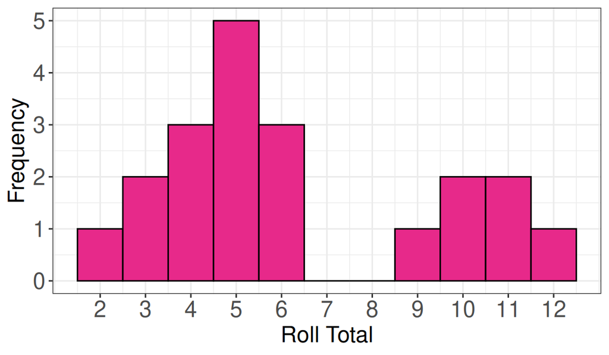

**Answer:** 6.3

**Solution:**

Each bar shows the number of times a certain value was rolled. Therefore the mean is . . .

$\frac{2+3+3+4+4+4+5+5+5+5+5+6+6+6+9+10+10+11+11+12}{20} = \frac{126}{20} = 6.30$

or more simply using a weighted mean . . .

$\frac{2×1 + 3×2 + 4×3 + 5×5 + 6×3 + 9×1 + 10×2 + 11×2 + 12×1}{1+2+3+5+3+1+2+2+1} = \frac{126}{20} = 6.30$

**R Code:**

```
x <- c(2, 3, 4, 5, 6, 9, 10, 11, 12) # values to average
w <- c(1, 2, 3, 5, 3, 1, 2, 2, 1) # weights

sum(x * w) / sum(w)
```

Crystal rolled two six-sided die and plotted their values on the histogram below. What was the mean value they obtained?

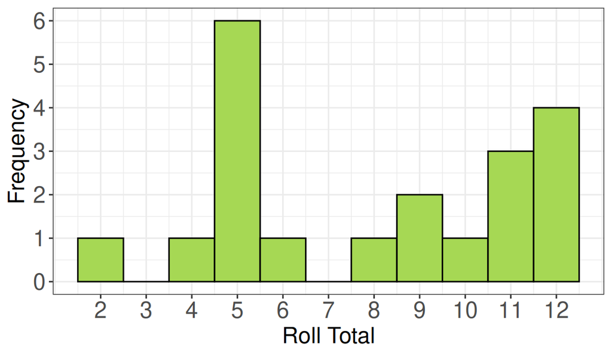

**Answer:** 7.95

**Solution:**

Each bar shows the number of times a certain value was rolled. Therefore the mean is . . .

$\frac{2+4+5+5+5+5+5+5+6+8+9+9+10+11+11+11+12+12+12+12}{20} = \frac{159}{20} = 7.95$

or more simply using a weighted mean . . .

$\frac{2×1 + 4×1 + 5×6 + 6×1 + 8×1 + 9×2 + 10×1 + 11×3 + 12×4}{1+1+6+1+1+2+1+3+4} = \frac{159}{20} = 7.95$

**R Code:**

```
x <- c(2, 4, 5, 6, 8, 9, 10, 11, 12) # values to average
w <- c(1, 1, 6, 1, 1, 2, 1, 3, 4) # weights

sum(x * w) / sum(w)
```

Devin rolled two six-sided die and plotted their values on the histogram below. What was the mean value they obtained?

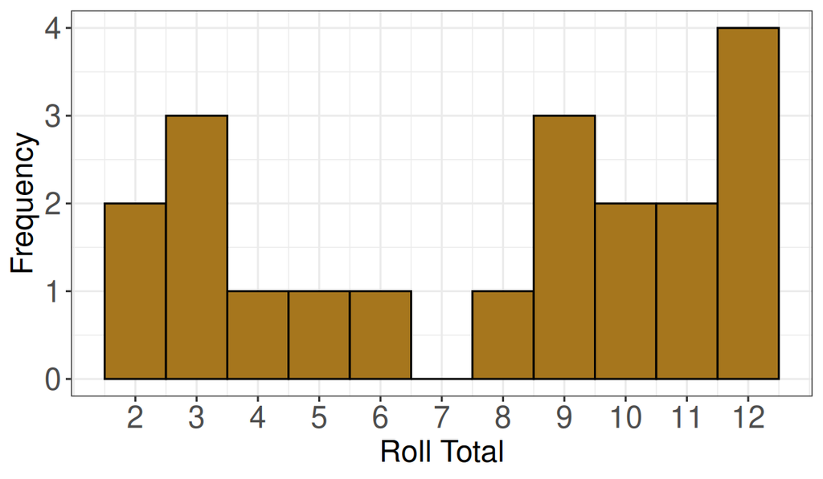

**Answer:** 7.65

**Solution:**

Each bar shows the number of times a certain value was rolled. Therefore the mean is . . .

$\frac{2+2+3+3+3+4+5+6+8+9+9+9+10+10+11+11+12+12+12+12}{20} = \frac{153}{20} = 7.65$

or more simply using a weighted mean . . .

$\frac{2×2 + 3×3 + 4×1 + 5×1 + 6×1 + 8×1 + 9×3 + 10×2 + 11×2 + 12×4}{2+3+1+1+1+1+3+2+2+4} = \frac{153}{20} = 7.65$

**R Code:**

```
x <- c(2, 3, 4, 5, 6, 8, 9, 10, 11, 12) # values to average
w <- c(2, 3, 1, 1, 1, 1, 3, 2, 2, 4) # weights

sum(x * w) / sum(w)
```

Andrew rolled two six-sided die and plotted their values on the histogram below. What was the mean value they obtained?

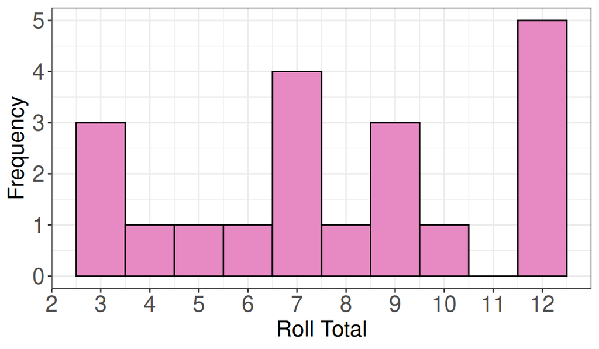

**Answer:** 7.85

**Solution:**

Each bar shows the number of times a certain value was rolled. Therefore the mean is . . .

$\frac{3+3+3+4+5+6+7+7+7+7+8+9+9+9+10+12+12+12+12+12}{20} = \frac{157}{20} = 7.85$

or more simply using a weighted mean . . .

$\frac{3×3 + 4×1 + 5×1 + 6×1 + 7×4 + 8×1 + 9×3 + 10×1 + 12×5}{3+1+1+1+4+1+3+1+5} = \frac{157}{20} = 7.85$

**R Code:**

```
x <- c(3, 4, 5, 6, 7, 8, 9, 10, 12) # values to average
w <- c(3, 1, 1, 1, 4, 1, 3, 1, 5) # weights

sum(x * w) / sum(w)
```

Caleb rolled two six-sided die and plotted their values on the histogram below. What was the mean value they obtained?

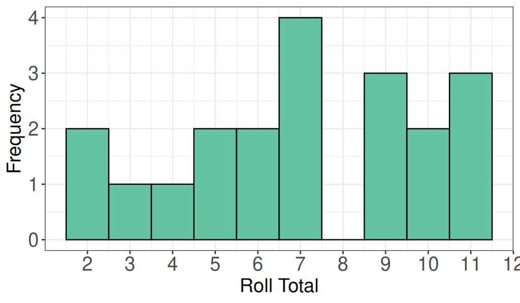

**Answer:** 7.05

**Solution:**

Each bar shows the number of times a certain value was rolled. Therefore the mean is . . .

$\frac{2+2+3+4+5+5+6+6+7+7+7+7+9+9+9+10+10+11+11+11}{20} = \frac{141}{20} = 7.05$

or more simply using a weighted mean . . .

$\frac{2×2 + 3×1 + 4×1 + 5×2 + 6×2 + 7×4 + 9×3 + 10×2 + 11×3}{2+1+1+2+2+4+3+2+3} = \frac{141}{20} = 7.05$

**R Code:**

```
x <- c(2, 3, 4, 5, 6, 7, 9, 10, 11) # values to average
w <- c(2, 1, 1, 2, 2, 4, 3, 2, 3) # weights

sum(x * w) / sum(w)
```

Patrick rolled two six-sided die and plotted their values on the histogram below. What was the mean value they obtained?

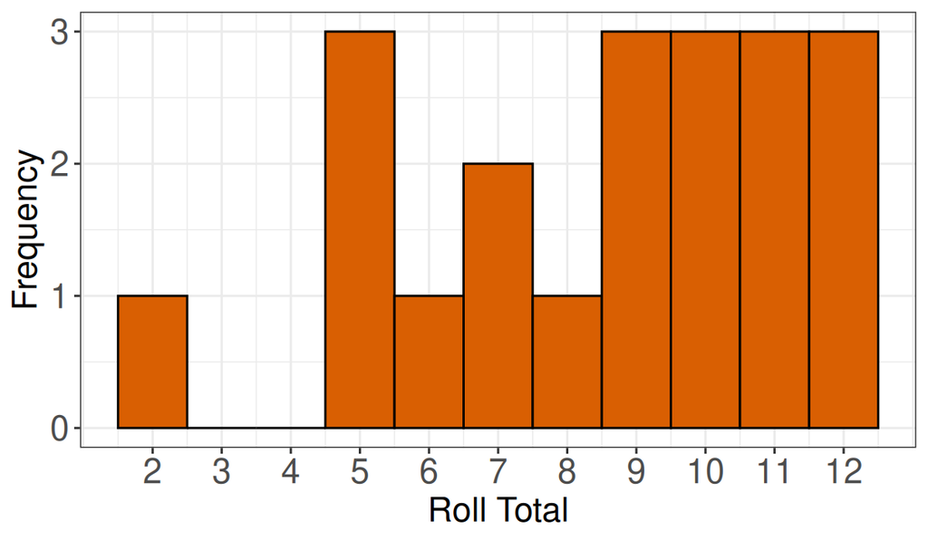

**Answer:** 8.55

**Solution:**

Each bar shows the number of times a certain value was rolled. Therefore the mean is . . .

$\frac{2+5+5+5+6+7+7+8+9+9+9+10+10+10+11+11+11+12+12+12}{20} = \frac{171}{20} = 8.55$

or more simply using a weighted mean . . .

$\frac{2×1 + 5×3 + 6×1 + 7×2 + 8×1 + 9×3 + 10×3 + 11×3 + 12×3}{1+3+1+2+1+3+3+3+3} = \frac{171}{20} = 8.55$

**R Code:**

```
x <- c(2, 5, 6, 7, 8, 9, 10, 11, 12) # values to average
w <- c(1, 3, 1, 2, 1, 3, 3, 3, 3) # weights

sum(x * w) / sum(w)
```

Sydney rolled two six-sided die and plotted their values on the histogram below. What was the mean value they obtained?

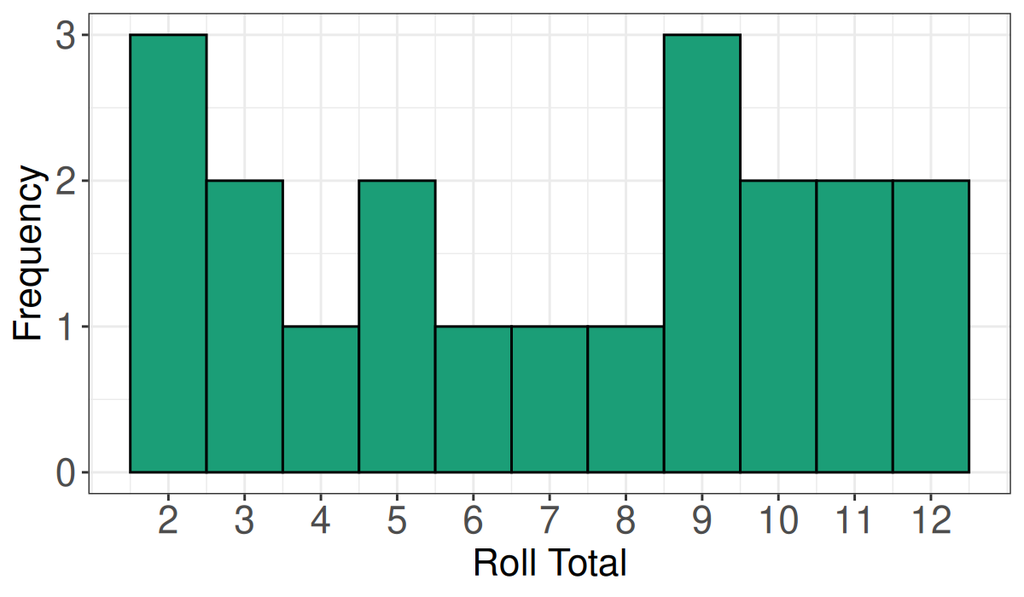

**Answer:** 7

**Solution:**

Each bar shows the number of times a certain value was rolled. Therefore the mean is . . .

$\frac{2+2+2+3+3+4+5+5+6+7+8+9+9+9+10+10+11+11+12+12}{20} = \frac{140}{20} = 7.00$

or more simply using a weighted mean . . .

$\frac{2×3 + 3×2 + 4×1 + 5×2 + 6×1 + 7×1 + 8×1 + 9×3 + 10×2 + 11×2 + 12×2}{3+2+1+2+1+1+1+3+2+2+2} = \frac{140}{20} = 7.00$

**R Code:**

```
x <- c(2, 3, 4, 5, 6, 7, 8, 9, 10, 11, 12) # values to average
w <- c(3, 2, 1, 2, 1, 1, 1, 3, 2, 2, 2) # weights

sum(x * w) / sum(w)
```

Karlee rolled two six-sided die and plotted their values on the histogram below. What was the mean value they obtained?

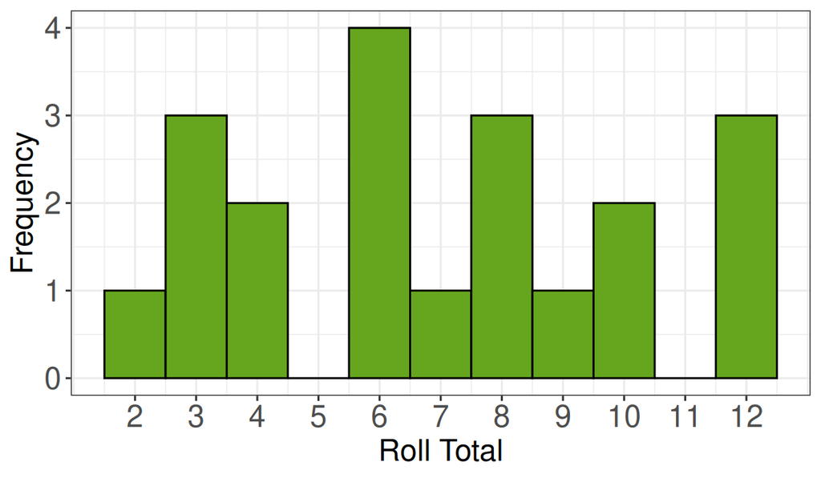

**Answer:** 6.95

**Solution:**

Each bar shows the number of times a certain value was rolled. Therefore the mean is . . .

$\frac{2+3+3+3+4+4+6+6+6+6+7+8+8+8+9+10+10+12+12+12}{20} = \frac{139}{20} = 6.95$

or more simply using a weighted mean . . .

$\frac{2×1 + 3×3 + 4×2 + 6×4 + 7×1 + 8×3 + 9×1 + 10×2 + 12×3}{1+3+2+4+1+3+1+2+3} = \frac{139}{20} = 6.95$

**R Code:**

```
x <- c(2, 3, 4, 6, 7, 8, 9, 10, 12) # values to average
w <- c(1, 3, 2, 4, 1, 3, 1, 2, 3) # weights

sum(x * w) / sum(w)
```

Alex rolled two six-sided die and plotted their values on the histogram below. What was the mean value they obtained?

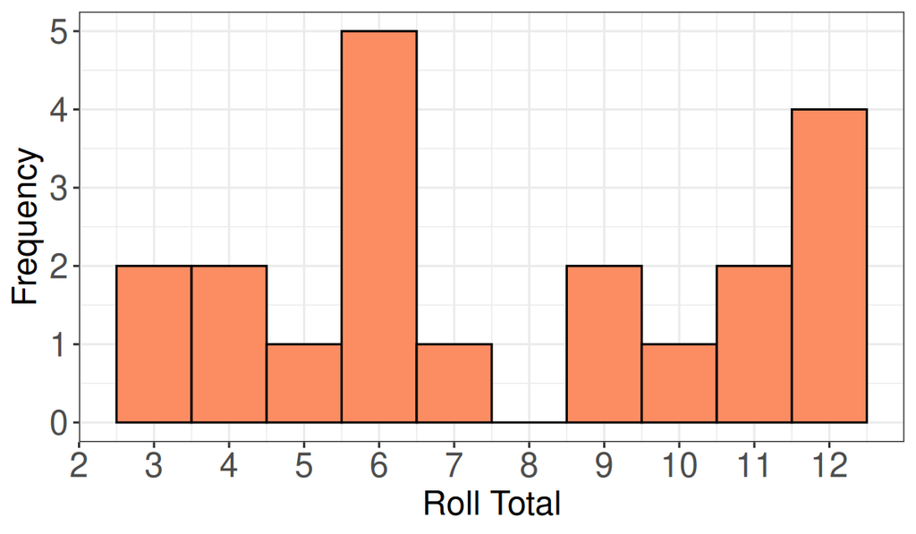

**Answer:** 7.7

**Solution:**

Each bar shows the number of times a certain value was rolled. Therefore the mean is . . .

$\frac{3+3+4+4+5+6+6+6+6+6+7+9+9+10+11+11+12+12+12+12}{20} = \frac{154}{20} = 7.70$

or more simply using a weighted mean . . .

$\frac{3×2 + 4×2 + 5×1 + 6×5 + 7×1 + 9×2 + 10×1 + 11×2 + 12×4}{2+2+1+5+1+2+1+2+4} = \frac{154}{20} = 7.70$

**R Code:**

```
x <- c(3, 4, 5, 6, 7, 9, 10, 11, 12) # values to average
w <- c(2, 2, 1, 5, 1, 2, 1, 2, 4) # weights

sum(x * w) / sum(w)
```

Jennifer rolled two six-sided die and plotted their values on the histogram below. What was the mean value they obtained?

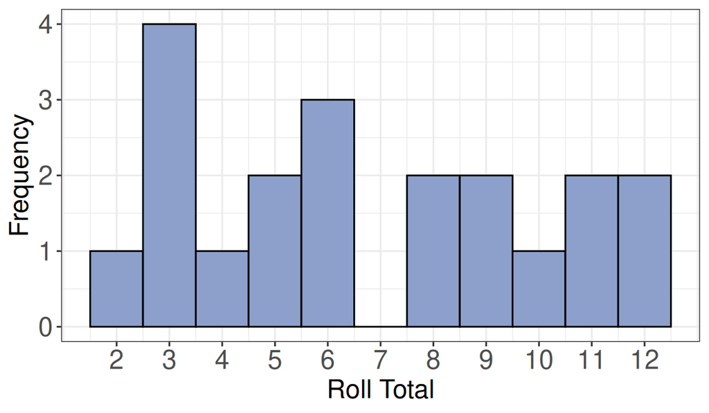

**Answer:** 6.8

**Solution:**

Each bar shows the number of times a certain value was rolled. Therefore the mean is . . .

$\frac{2+3+3+3+3+4+5+5+6+6+6+8+8+9+9+10+11+11+12+12}{20} = \frac{136}{20} = 6.80$

or more simply using a weighted mean . . .

$\frac{2×1 + 3×4 + 4×1 + 5×2 + 6×3 + 8×2 + 9×2 + 10×1 + 11×2 + 12×2}{1+4+1+2+3+2+2+1+2+2} = \frac{136}{20} = 6.80$

**R Code:**

```
x <- c(2, 3, 4, 5, 6, 8, 9, 10, 11, 12) # values to average
w <- c(1, 4, 1, 2, 3, 2, 2, 1, 2, 2) # weights

sum(x * w) / sum(w)
```

Which measure of central tendency provides the best description of this plot?

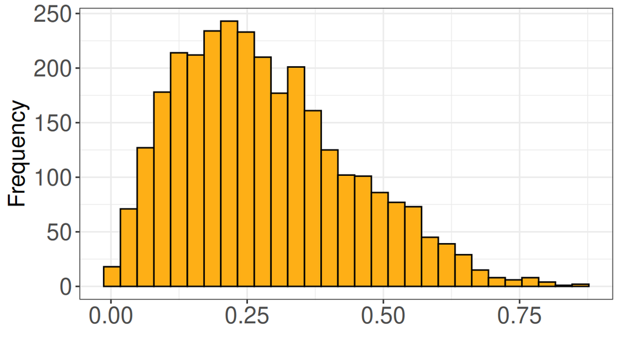

Mean or MedianMeanMedian

In positively skewed distributions like this, extreme values in the right tail distort the mean by pulling it away from the peak, making it a less accurate measure of central tendency. The median's resistance to outliers makes it the superior descriptor in this case.

Which measure of central tendency provides the best description of this plot?

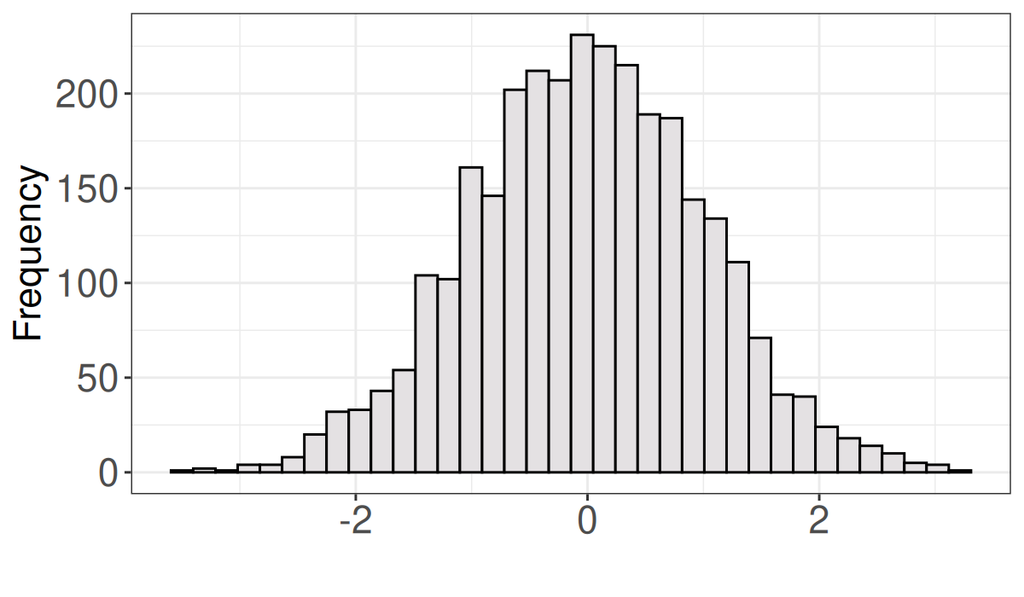

MeanMean or MedianMedian

For a symmetric unimodal distribution, the mean and median are equivalent.

Which measure of central tendency provides the best description of this plot?

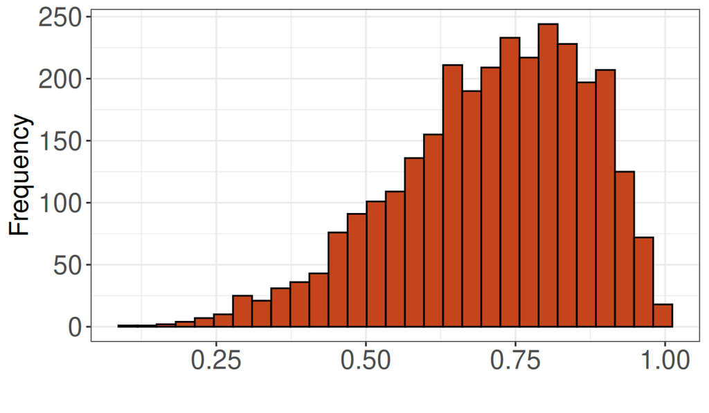

MeanMean or MedianMedian

In negatively skewed distributions like this, extreme values in the left tail distort the mean by pulling it away from the peak, making it a less accurate measure of central tendency. The median's resistance to outliers makes it the superior descriptor in this case.

Which measure of central tendency provides the best description of this plot?

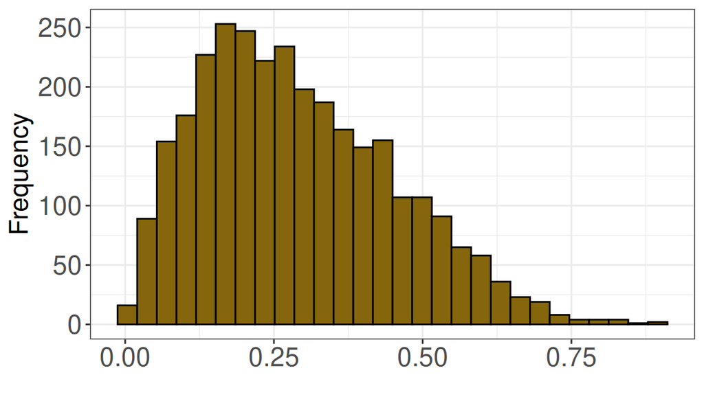

MedianMean or MedianMean

In positively skewed distributions like this, extreme values in the right tail distort the mean by pulling it away from the peak, making it a less accurate measure of central tendency. The median's resistance to outliers makes it the superior descriptor in this case.

Which measure of central tendency provides the best description of this plot?

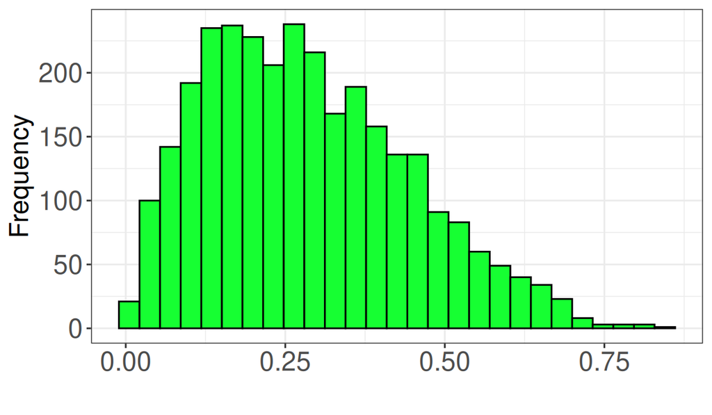

MedianMeanMean or Median

In positively skewed distributions like this, extreme values in the right tail distort the mean by pulling it away from the peak, making it a less accurate measure of central tendency. The median's resistance to outliers makes it the superior descriptor in this case.

Which measure of central tendency provides the best description of this plot?

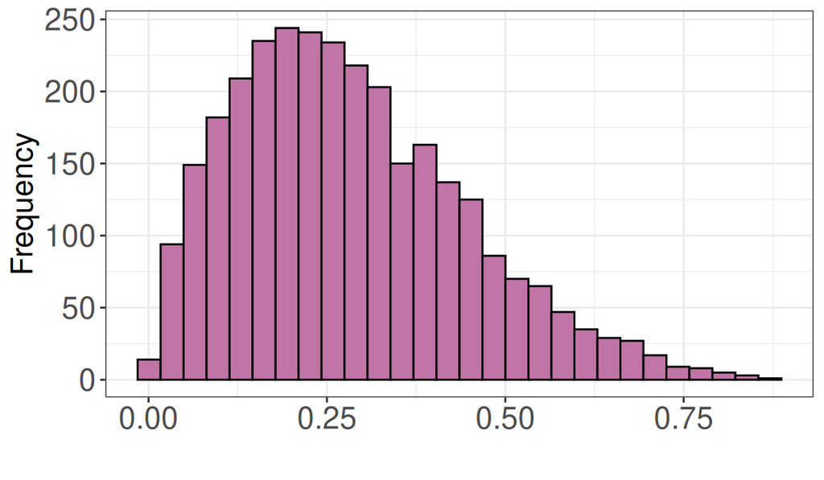

Mean or MedianMeanMedian

In positively skewed distributions like this, extreme values in the right tail distort the mean by pulling it away from the peak, making it a less accurate measure of central tendency. The median's resistance to outliers makes it the superior descriptor in this case.

Which measure of central tendency provides the best description of this plot?

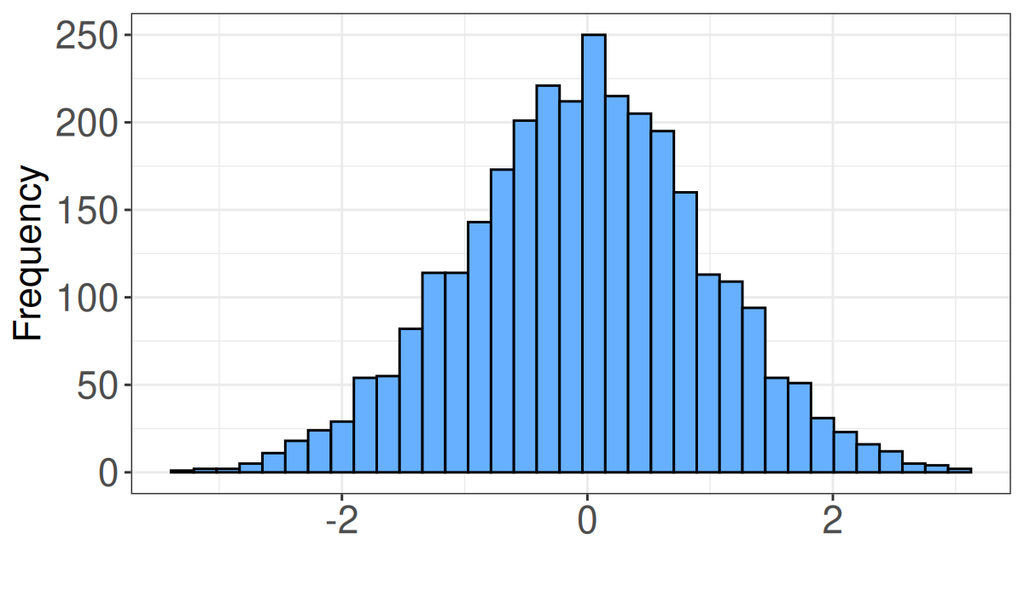

MeanMean or MedianMedian

For a symmetric unimodal distribution, the mean and median are equivalent.

Which measure of central tendency provides the best description of this plot?

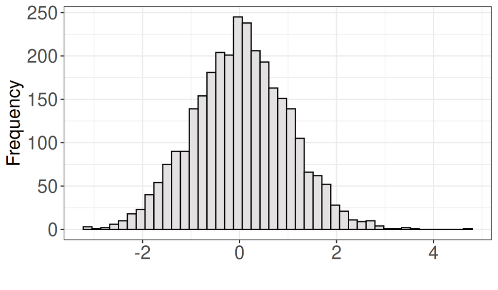

Mean or MedianMedianMean

For a symmetric unimodal distribution, the mean and median are equivalent.

Which measure of central tendency provides the best description of this plot?

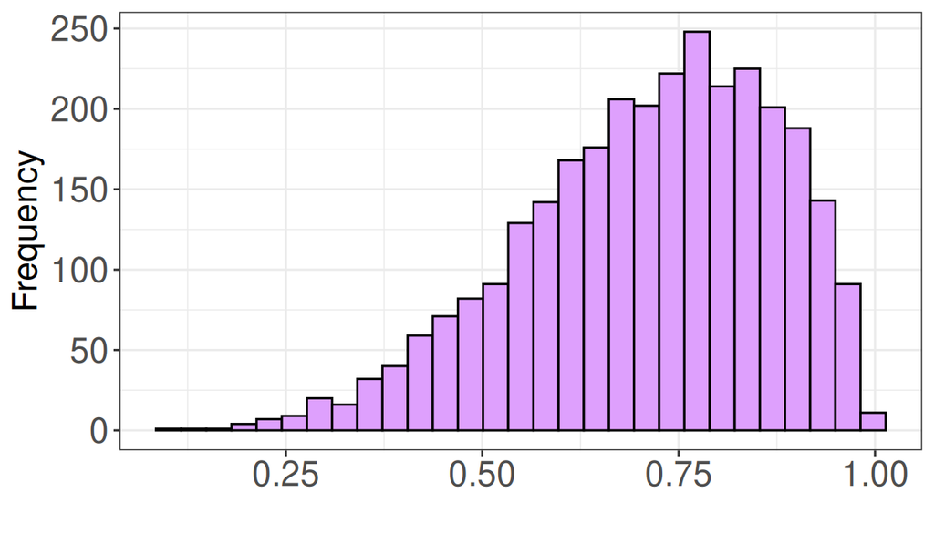

MeanMean or MedianMedian

In negatively skewed distributions like this, extreme values in the left tail distort the mean by pulling it away from the peak, making it a less accurate measure of central tendency. The median's resistance to outliers makes it the superior descriptor in this case.

Which measure of central tendency provides the best description of this plot?

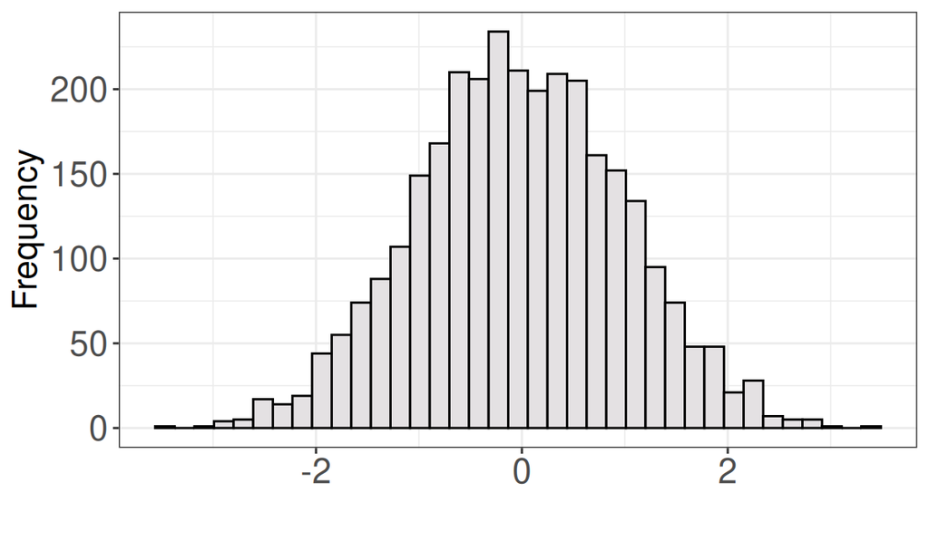

MedianMean or MedianMean

For a symmetric unimodal distribution, the mean and median are equivalent.

Mode > Median > MeanMean < Median > ModeMedian > Mode > MeanMedian > Mean > ModeMedian < Mode > MeanMean > Median > Mode

Extreme values on the right side will pull the mean towards the right the most, followed by the median, and then the mode.

Values on the right side of the x-axis have a larger numerical value than values on the left.

Thus, the answer is Mean > Median > Mode

Mean < Median > ModeMedian > Mode > MeanMean > Median > ModeMedian < Mode > MeanMedian > Mean > ModeMode > Median > Mean

Extreme values on the right side will pull the mean towards the right the most, followed by the median, and then the mode.

Values on the right side of the x-axis have a larger numerical value than values on the left.

Thus, the answer is Mean > Median > Mode

Median < Mode > MeanMode > Median > MeanMedian > Mean > ModeMedian > Mode > MeanMean < Median > ModeMean > Median > Mode

Extreme values on the right side will pull the mean towards the right the most, followed by the median, and then the mode.

Values on the right side of the x-axis have a larger numerical value than values on the left.

Thus, the answer is Mean > Median > Mode

Mean > Median > ModeMedian > Mean > ModeMean < Median > ModeMedian > Mode > MeanMode > Median > MeanMedian < Mode > Mean

Extreme values on the right side will pull the mean towards the right the most, followed by the median, and then the mode.

Values on the right side of the x-axis have a larger numerical value than values on the left.

Thus, the answer is Mean > Median > Mode

Median > Mean > ModeMode > Median > MeanMedian < Mode > MeanMean < Median > ModeMedian > Mode > MeanMean > Median > Mode

Extreme values on the right side will pull the mean towards the right the most, followed by the median, and then the mode.

Values on the right side of the x-axis have a larger numerical value than values on the left.

Thus, the answer is Mean > Median > Mode

Mean > Median > ModeMedian > Mode > MeanMedian > Mean > ModeMean < Median > ModeMedian < Mode > MeanMode > Median > Mean

Extreme values on the right side will pull the mean towards the right the most, followed by the median, and then the mode.

Values on the right side of the x-axis have a larger numerical value than values on the left.

Thus, the answer is Mean > Median > Mode

Median < Mode > MeanMode > Median > MeanMedian > Mode > MeanMean > Median > ModeMedian > Mean > ModeMean < Median > Mode

Extreme values on the right side will pull the mean towards the right the most, followed by the median, and then the mode.

Values on the right side of the x-axis have a larger numerical value than values on the left.

Thus, the answer is Mean > Median > Mode

Mode > Median > MeanMedian < Mode > MeanMean > Median > ModeMedian > Mode > MeanMedian > Mean > ModeMean < Median > Mode

Extreme values on the right side will pull the mean towards the right the most, followed by the median, and then the mode.

Values on the right side of the x-axis have a larger numerical value than values on the left.

Thus, the answer is Mean > Median > Mode

Median > Mean > ModeMean < Median > ModeMedian < Mode > MeanMedian > Mode > MeanMean > Median > ModeMode > Median > Mean

Extreme values on the right side will pull the mean towards the right the most, followed by the median, and then the mode.

Values on the right side of the x-axis have a larger numerical value than values on the left.

Thus, the answer is Mean > Median > Mode

Mean > Median > ModeMode > Median > MeanMedian < Mode > MeanMedian > Mode > MeanMedian > Mean > ModeMean < Median > Mode

Extreme values on the right side will pull the mean towards the right the most, followed by the median, and then the mode.

Values on the right side of the x-axis have a larger numerical value than values on the left.

Thus, the answer is Mean > Median > Mode

Load the data file **BFD_skew_4.csv** ([Access the data file here](https://jpisklak.github.io/courses/PSYCH_213_A1/data_files.html#skewed_data)).

Note: This file is quite large, so it may take a few seconds to appear in Colab’s sidebar. It is recommended that you use the Raw URL instead for faster and more reliable access. Please also avoid trying to open it in standard spreadsheet programs (like Excel), as it’s too big to load properly.

The data file only has one column. Load the file and determine if its data is negatively skewed, positively skewed, or symmetric. If it is skewed, calculate the median, if it is symmetric, calculate the mean.

**Answer:** 20.5397341

**R code:**

```
library(tidyverse)
data <- read_csv("BFD_skew_4.csv")

# Look at distribution
ggplot(data, aes(x = col_1)) +
  geom_histogram(colour = "black", fill = "deeppink1")

median(data$col_1)
```

Load the data file **BFD_skew_3.csv** ([Access the data file here](https://jpisklak.github.io/courses/PSYCH_213_A1/data_files.html#skewed_data)).

Note: This file is quite large, so it may take a few seconds to appear in Colab’s sidebar. It is recommended that you use the Raw URL instead for faster and more reliable access. Please also avoid trying to open it in standard spreadsheet programs (like Excel), as it’s too big to load properly.

The data file only has one column. Load the file and determine if its data is negatively skewed, positively skewed, or symmetric. If it is skewed, calculate the median, if it is symmetric, calculate the mean.

**Answer:** 39.451195

**R code:**

```
library(tidyverse)
data <- read_csv("BFD_skew_3.csv")

# Look at distribution
ggplot(data, aes(x = col_1)) +
  geom_histogram(colour = "black", fill = "deeppink1")

mean(data$col_1)
```

Load the data file **BFD_skew_5.csv** ([Access the data file here](https://jpisklak.github.io/courses/PSYCH_213_A1/data_files.html#skewed_data)).

Note: This file is quite large, so it may take a few seconds to appear in Colab’s sidebar. It is recommended that you use the Raw URL instead for faster and more reliable access. Please also avoid trying to open it in standard spreadsheet programs (like Excel), as it’s too big to load properly.

The data file only has one column. Load the file and determine if its data is negatively skewed, positively skewed, or symmetric. If it is skewed, calculate the median, if it is symmetric, calculate the mean.

**Answer:** 13.7760941

**R code:**

```
library(tidyverse)
data <- read_csv("BFD_skew_5.csv")

# Look at distribution
ggplot(data, aes(x = col_1)) +
  geom_histogram(colour = "black", fill = "deeppink1")

mean(data$col_1)
```

Load the data file **BFD_skew_5.csv** ([Access the data file here](https://jpisklak.github.io/courses/PSYCH_213_A1/data_files.html#skewed_data)).

Note: This file is quite large, so it may take a few seconds to appear in Colab’s sidebar. It is recommended that you use the Raw URL instead for faster and more reliable access. Please also avoid trying to open it in standard spreadsheet programs (like Excel), as it’s too big to load properly.

The data file only has one column. Load the file and determine if its data is negatively skewed, positively skewed, or symmetric. If it is skewed, calculate the median, if it is symmetric, calculate the mean.

**Answer:** 13.7760941

**R code:**

```
library(tidyverse)
data <- read_csv("BFD_skew_5.csv")

# Look at distribution
ggplot(data, aes(x = col_1)) +
  geom_histogram(colour = "black", fill = "deeppink1")

mean(data$col_1)
```

Load the data file **BFD_skew_2.csv** ([Access the data file here](https://jpisklak.github.io/courses/PSYCH_213_A1/data_files.html#skewed_data)).

Note: This file is quite large, so it may take a few seconds to appear in Colab’s sidebar. It is recommended that you use the Raw URL instead for faster and more reliable access. Please also avoid trying to open it in standard spreadsheet programs (like Excel), as it’s too big to load properly.

The data file only has one column. Load the file and determine if its data is negatively skewed, positively skewed, or symmetric. If it is skewed, calculate the median, if it is symmetric, calculate the mean.

**Answer:** 25.66442

**R code:**

```
library(tidyverse)
data <- read_csv("BFD_skew_2.csv")

# Look at distribution
ggplot(data, aes(x = col_1)) +
  geom_histogram(colour = "black", fill = "deeppink1")

median(data$col_1)
```

Load the data file **BFD_skew_4.csv** ([Access the data file here](https://jpisklak.github.io/courses/PSYCH_213_A1/data_files.html#skewed_data)).

Note: This file is quite large, so it may take a few seconds to appear in Colab’s sidebar. It is recommended that you use the Raw URL instead for faster and more reliable access. Please also avoid trying to open it in standard spreadsheet programs (like Excel), as it’s too big to load properly.

The data file only has one column. Load the file and determine if its data is negatively skewed, positively skewed, or symmetric. If it is skewed, calculate the median, if it is symmetric, calculate the mean.

**Answer:** 20.5397341

**R code:**

```
library(tidyverse)
data <- read_csv("BFD_skew_4.csv")

# Look at distribution
ggplot(data, aes(x = col_1)) +
  geom_histogram(colour = "black", fill = "deeppink1")

median(data$col_1)
```

Load the data file **BFD_skew_1.csv** ([Access the data file here](https://jpisklak.github.io/courses/PSYCH_213_A1/data_files.html#skewed_data)).

Note: This file is quite large, so it may take a few seconds to appear in Colab’s sidebar. It is recommended that you use the Raw URL instead for faster and more reliable access. Please also avoid trying to open it in standard spreadsheet programs (like Excel), as it’s too big to load properly.

The data file only has one column. Load the file and determine if its data is negatively skewed, positively skewed, or symmetric. If it is skewed, calculate the median, if it is symmetric, calculate the mean.

**Answer:** 66.245699

**R code:**

```
library(tidyverse)
data <- read_csv("BFD_skew_1.csv")

# Look at distribution
ggplot(data, aes(x = col_1)) +
  geom_histogram(colour = "black", fill = "deeppink1")

median(data$col_1)
```

Load the data file **BFD_skew_3.csv** ([Access the data file here](https://jpisklak.github.io/courses/PSYCH_213_A1/data_files.html#skewed_data)).

Note: This file is quite large, so it may take a few seconds to appear in Colab’s sidebar. It is recommended that you use the Raw URL instead for faster and more reliable access. Please also avoid trying to open it in standard spreadsheet programs (like Excel), as it’s too big to load properly.

The data file only has one column. Load the file and determine if its data is negatively skewed, positively skewed, or symmetric. If it is skewed, calculate the median, if it is symmetric, calculate the mean.

**Answer:** 39.451195

**R code:**

```
library(tidyverse)
data <- read_csv("BFD_skew_3.csv")

# Look at distribution
ggplot(data, aes(x = col_1)) +
  geom_histogram(colour = "black", fill = "deeppink1")

mean(data$col_1)
```

Load the data file **BFD_skew_3.csv** ([Access the data file here](https://jpisklak.github.io/courses/PSYCH_213_A1/data_files.html#skewed_data)).

Note: This file is quite large, so it may take a few seconds to appear in Colab’s sidebar. It is recommended that you use the Raw URL instead for faster and more reliable access. Please also avoid trying to open it in standard spreadsheet programs (like Excel), as it’s too big to load properly.

The data file only has one column. Load the file and determine if its data is negatively skewed, positively skewed, or symmetric. If it is skewed, calculate the median, if it is symmetric, calculate the mean.

**Answer:** 39.451195

**R code:**

```
library(tidyverse)
data <- read_csv("BFD_skew_3.csv")

# Look at distribution
ggplot(data, aes(x = col_1)) +
  geom_histogram(colour = "black", fill = "deeppink1")

mean(data$col_1)
```

Load the data file **BFD_skew_3.csv** ([Access the data file here](https://jpisklak.github.io/courses/PSYCH_213_A1/data_files.html#skewed_data)).

Note: This file is quite large, so it may take a few seconds to appear in Colab’s sidebar. It is recommended that you use the Raw URL instead for faster and more reliable access. Please also avoid trying to open it in standard spreadsheet programs (like Excel), as it’s too big to load properly.

The data file only has one column. Load the file and determine if its data is negatively skewed, positively skewed, or symmetric. If it is skewed, calculate the median, if it is symmetric, calculate the mean.

**Answer:** 39.451195

**R code:**

```
library(tidyverse)
data <- read_csv("BFD_skew_3.csv")

# Look at distribution
ggplot(data, aes(x = col_1)) +
  geom_histogram(colour = "black", fill = "deeppink1")

mean(data$col_1)
```

R has a function called `nrow()`. Do some *quick* research online and determine what this function does. How is it different from the `length()` function we have used?

Tip: Instead of looking online, try inserting a dataframe and a vector separately into each of these functions (i.e., experiment and see what happens).

Which of the following statements is correct?

`nrow()` returns the number of columns in a data frame, while `length()` returns the number of rows.`nrow()` returns the number of rows in a data frame, while `length()` returns the total number of elements in a vector.`nrow()` and `length()` always return the same value when used on data frames.`nrow()` works for both vectors and data frames, whereas `length()` only works for data frames.

- For a dataframe, `nrow(df)` returns the number of rows in a data frame or matrix. `length(df)` returns the number of columns in a data frame.
- For a vector, `length(vec)` gives the total number of elements, but `nrow(vec)` returns NULL because vectors don’t have rows.

R has a function called `nrow()`. Do some *quick* research online and determine what this function does. How is it different from the `length()` function we have used?

Tip: Instead of looking online, try inserting a dataframe and a vector separately into each of these functions (i.e., experiment and see what happens).

Which of the following statements is correct?

`nrow()` works for both vectors and data frames, whereas `length()` only works for data frames.`nrow()` returns the number of columns in a data frame, while `length()` returns the number of rows.`nrow()` and `length()` always return the same value when used on data frames.`nrow()` returns the number of rows in a data frame, while `length()` returns the total number of elements in a vector.

- For a dataframe, `nrow(df)` returns the number of rows in a data frame or matrix. `length(df)` returns the number of columns in a data frame.
- For a vector, `length(vec)` gives the total number of elements, but `nrow(vec)` returns NULL because vectors don’t have rows.

R has a function called `nrow()`. Do some *quick* research online and determine what this function does. How is it different from the `length()` function we have used?

Tip: Instead of looking online, try inserting a dataframe and a vector separately into each of these functions (i.e., experiment and see what happens).

Which of the following statements is correct?

`nrow()` returns the number of rows in a data frame, while `length()` returns the total number of elements in a vector.`nrow()` and `length()` always return the same value when used on data frames.`nrow()` returns the number of columns in a data frame, while `length()` returns the number of rows.`nrow()` works for both vectors and data frames, whereas `length()` only works for data frames.

- For a dataframe, `nrow(df)` returns the number of rows in a data frame or matrix. `length(df)` returns the number of columns in a data frame.
- For a vector, `length(vec)` gives the total number of elements, but `nrow(vec)` returns NULL because vectors don’t have rows.

R has a function called `nrow()`. Do some *quick* research online and determine what this function does. How is it different from the `length()` function we have used?

Tip: Instead of looking online, try inserting a dataframe and a vector separately into each of these functions (i.e., experiment and see what happens).

Which of the following statements is correct?

`nrow()` and `length()` always return the same value when used on data frames.`nrow()` returns the number of rows in a data frame, while `length()` returns the total number of elements in a vector.`nrow()` works for both vectors and data frames, whereas `length()` only works for data frames.`nrow()` returns the number of columns in a data frame, while `length()` returns the number of rows.

- For a dataframe, `nrow(df)` returns the number of rows in a data frame or matrix. `length(df)` returns the number of columns in a data frame.
- For a vector, `length(vec)` gives the total number of elements, but `nrow(vec)` returns NULL because vectors don’t have rows.

R has a function called `nrow()`. Do some *quick* research online and determine what this function does. How is it different from the `length()` function we have used?

Tip: Instead of looking online, try inserting a dataframe and a vector separately into each of these functions (i.e., experiment and see what happens).

Which of the following statements is correct?

`nrow()` returns the number of rows in a data frame, while `length()` returns the total number of elements in a vector.`nrow()` works for both vectors and data frames, whereas `length()` only works for data frames.`nrow()` returns the number of columns in a data frame, while `length()` returns the number of rows.`nrow()` and `length()` always return the same value when used on data frames.

- For a dataframe, `nrow(df)` returns the number of rows in a data frame or matrix. `length(df)` returns the number of columns in a data frame.
- For a vector, `length(vec)` gives the total number of elements, but `nrow(vec)` returns NULL because vectors don’t have rows.

R has a function called `nrow()`. Do some *quick* research online and determine what this function does. How is it different from the `length()` function we have used?

Tip: Instead of looking online, try inserting a dataframe and a vector separately into each of these functions (i.e., experiment and see what happens).

Which of the following statements is correct?

`nrow()` returns the number of columns in a data frame, while `length()` returns the number of rows.`nrow()` works for both vectors and data frames, whereas `length()` only works for data frames.`nrow()` and `length()` always return the same value when used on data frames.`nrow()` returns the number of rows in a data frame, while `length()` returns the total number of elements in a vector.

- For a dataframe, `nrow(df)` returns the number of rows in a data frame or matrix. `length(df)` returns the number of columns in a data frame.
- For a vector, `length(vec)` gives the total number of elements, but `nrow(vec)` returns NULL because vectors don’t have rows.

R has a function called `nrow()`. Do some *quick* research online and determine what this function does. How is it different from the `length()` function we have used?

Tip: Instead of looking online, try inserting a dataframe and a vector separately into each of these functions (i.e., experiment and see what happens).

Which of the following statements is correct?

`nrow()` returns the number of columns in a data frame, while `length()` returns the number of rows.`nrow()` returns the number of rows in a data frame, while `length()` returns the total number of elements in a vector.`nrow()` and `length()` always return the same value when used on data frames.`nrow()` works for both vectors and data frames, whereas `length()` only works for data frames.

- For a dataframe, `nrow(df)` returns the number of rows in a data frame or matrix. `length(df)` returns the number of columns in a data frame.
- For a vector, `length(vec)` gives the total number of elements, but `nrow(vec)` returns NULL because vectors don’t have rows.

R has a function called `nrow()`. Do some *quick* research online and determine what this function does. How is it different from the `length()` function we have used?

Tip: Instead of looking online, try inserting a dataframe and a vector separately into each of these functions (i.e., experiment and see what happens).

Which of the following statements is correct?

`nrow()` returns the number of columns in a data frame, while `length()` returns the number of rows.`nrow()` works for both vectors and data frames, whereas `length()` only works for data frames.`nrow()` and `length()` always return the same value when used on data frames.`nrow()` returns the number of rows in a data frame, while `length()` returns the total number of elements in a vector.

- For a dataframe, `nrow(df)` returns the number of rows in a data frame or matrix. `length(df)` returns the number of columns in a data frame.
- For a vector, `length(vec)` gives the total number of elements, but `nrow(vec)` returns NULL because vectors don’t have rows.

R has a function called `nrow()`. Do some *quick* research online and determine what this function does. How is it different from the `length()` function we have used?

Tip: Instead of looking online, try inserting a dataframe and a vector separately into each of these functions (i.e., experiment and see what happens).

Which of the following statements is correct?

`nrow()` returns the number of columns in a data frame, while `length()` returns the number of rows.`nrow()` works for both vectors and data frames, whereas `length()` only works for data frames.`nrow()` returns the number of rows in a data frame, while `length()` returns the total number of elements in a vector.`nrow()` and `length()` always return the same value when used on data frames.

- For a dataframe, `nrow(df)` returns the number of rows in a data frame or matrix. `length(df)` returns the number of columns in a data frame.
- For a vector, `length(vec)` gives the total number of elements, but `nrow(vec)` returns NULL because vectors don’t have rows.

R has a function called `nrow()`. Do some *quick* research online and determine what this function does. How is it different from the `length()` function we have used?

Tip: Instead of looking online, try inserting a dataframe and a vector separately into each of these functions (i.e., experiment and see what happens).

Which of the following statements is correct?

`nrow()` returns the number of columns in a data frame, while `length()` returns the number of rows.`nrow()` works for both vectors and data frames, whereas `length()` only works for data frames.`nrow()` returns the number of rows in a data frame, while `length()` returns the total number of elements in a vector.`nrow()` and `length()` always return the same value when used on data frames.

- For a dataframe, `nrow(df)` returns the number of rows in a data frame or matrix. `length(df)` returns the number of columns in a data frame.
- For a vector, `length(vec)` gives the total number of elements, but `nrow(vec)` returns NULL because vectors don’t have rows.